# Los Anageles Restaurant and Market Health Analysis

Cheng Xie

```python
#pip install pandas
#pip install matplotlib
#pip install h2o
import  warnings
warnings.simplefilter('ignore')

import numpy as np
import pandas as pd
import seaborn as sns
import matplotlib.pyplot as plt
from sklearn.metrics import auc, roc_curve, classification_report

import h2o
from h2o.frame import H2OFrame
from h2o.estimators.random_forest import H2ORandomForestEstimator
```

## Data Loading

Inspection records

```python
df_inspect = pd.read_csv('/Users/zhangdoudou/Desktop/BD_Project/restaurant-and-market-health-inspections.csv', parse_dates=['activity_date'])
df_inspect.head()
```

|  | serial_number | activity_date | facility_name | score | grade | service_code | service_description | employee_id | facility_address | facility_city | facility_id | facility_state | facility_zip | owner_id | owner_name | pe_description | program_element_pe | program_name | program_status | record_id |
| --- | --- | --- | --- | --- | --- | --- | --- | --- | --- | --- | --- | --- | --- | --- | --- | --- | --- | --- | --- | --- |
| 0 | DAJ00E07B | 2017-12-29 | HABITAT COFFEE SHOP | 95 | A | 1 | ROUTINE INSPECTION | EE0000923 | 3708 N EAGLE ROCK BLVD | LOS ANGELES | FA0170465 | CA | 90065 | OW0178123 | GLASSELL COFFEE SHOP LLC | RESTAURANT (0-30) SEATS MODERATE RISK | 1631 | HABITAT COFFEE SHOP | ACTIVE | PR0160774 |
| 1 | DAQOKRFZB | 2017-12-29 | REILLY'S | 92 | A | 1 | ROUTINE INSPECTION | EE0000633 | 100 WORLD WAY # 120 | LOS ANGELES | FA0244690 | CA | 90045 | OW0208441 | AREAS SKYVIEW LAX JV, LLC | RESTAURANT (0-30) SEATS MODERATE RISK | 1631 | REILLY'S | ACTIVE | PR0193026 |
| 2 | DASJI4LUR | 2017-12-29 | STREET CHURROS | 93 | A | 1 | ROUTINE INSPECTION | EE0000835 | 6801 HOLLYWOOD BLVD # 253 | LOS ANGELES | FA0224109 | CA | 90028 | OW0228670 | STREETCHURROS, INC | RESTAURANT (0-30) SEATS LOW RISK | 1630 | STREET CHURROS | ACTIVE | PR0179282 |
| 3 | DAWVA0CY3 | 2017-12-29 | RIO GENTLEMANS CLUB | 93 | A | 1 | ROUTINE INSPECTION | EE0000958 | 13124 S FIGUEROA ST | LOS ANGELES | FA0046462 | CA | 90064 | OW0011830 | FIGUEROA GROUP INC | RESTAURANT (61-150) SEATS LOW RISK | 1636 | RIO GENTLEMANS CLUB | ACTIVE | PR0044776 |
| 4 | DAKFCHD0L | 2017-12-29 | LE PAIN QUOTIDIEN | 93 | A | 1 | ROUTINE INSPECTION | EE0000629 | 13050 SAN VICENTE BLVD STE 114 | LOS ANGELES | FA0034788 | CA | 90049 | OW0028928 | PQ SAN VICENTE INC. | RESTAURANT (61-150) SEATS HIGH RISK | 1638 | LE PAIN QUOTIDIEN | ACTIVE | PR0017456 |

```python
print(df_inspect.describe())
```

```
              score  service_code  program_element_pe
count  58872.000000  58872.000000        58872.000000
mean      93.307922      7.733252         1629.489282
std        3.996712     51.458809            9.397450
min       64.000000      1.000000         1610.000000
25%       91.000000      1.000000         1631.000000
50%       94.000000      1.000000         1632.000000
75%       96.000000      1.000000         1635.000000
max      100.000000    401.000000         1641.000000
```

violation records

```python
df_violate = pd.read_csv('/Users/zhangdoudou/Desktop/BD_Project/restaurant-and-market-health-violations.csv', parse_dates=['activity_date'])
df_violate.head()
```

|  | serial_number | activity_date | facility_name | violation_code | violation_description | violation_status | points | grade | facility_address | facility_city | ... | owner_name | pe_description | program_element_pe | program_name | program_status | record_id | score | service_code | service_description | row_id |
| --- | --- | --- | --- | --- | --- | --- | --- | --- | --- | --- | --- | --- | --- | --- | --- | --- | --- | --- | --- | --- | --- |
| 0 | DA08R0TCU | 2018-03-30 | KRUANG TEDD | F030 | # 30. Food properly stored; food storage conta... | OUT OF COMPLIANCE | 1 | A | 5151 HOLLYWOOD BLVD | LOS ANGELES | ... | 5151 HOLLYWOOD LLC | RESTAURANT (31-60) SEATS HIGH RISK | 1635 | KRUANG TEDD | ACTIVE | PR0031205 | 92 | 1 | ROUTINE INSPECTION | DA08R0TCUF030 |
| 1 | DA08R0TCU | 2018-03-30 | KRUANG TEDD | F027 | # 27. Food separated and protected | OUT OF COMPLIANCE | 1 | A | 5151 HOLLYWOOD BLVD | LOS ANGELES | ... | 5151 HOLLYWOOD LLC | RESTAURANT (31-60) SEATS HIGH RISK | 1635 | KRUANG TEDD | ACTIVE | PR0031205 | 92 | 1 | ROUTINE INSPECTION | DA08R0TCUF027 |
| 2 | DA08R0TCU | 2018-03-30 | KRUANG TEDD | F035 | # 35. Equipment/Utensils - approved; installed... | OUT OF COMPLIANCE | 1 | A | 5151 HOLLYWOOD BLVD | LOS ANGELES | ... | 5151 HOLLYWOOD LLC | RESTAURANT (31-60) SEATS HIGH RISK | 1635 | KRUANG TEDD | ACTIVE | PR0031205 | 92 | 1 | ROUTINE INSPECTION | DA08R0TCUF035 |
| 3 | DA08R0TCU | 2018-03-30 | KRUANG TEDD | F033 | # 33. Nonfood-contact surfaces clean and in go... | OUT OF COMPLIANCE | 1 | A | 5151 HOLLYWOOD BLVD | LOS ANGELES | ... | 5151 HOLLYWOOD LLC | RESTAURANT (31-60) SEATS HIGH RISK | 1635 | KRUANG TEDD | ACTIVE | PR0031205 | 92 | 1 | ROUTINE INSPECTION | DA08R0TCUF033 |
| 4 | DA08R0TCU | 2018-03-30 | KRUANG TEDD | F029 | # 29. Toxic substances properly identified, st... | OUT OF COMPLIANCE | 1 | A | 5151 HOLLYWOOD BLVD | LOS ANGELES | ... | 5151 HOLLYWOOD LLC | RESTAURANT (31-60) SEATS HIGH RISK | 1635 | KRUANG TEDD | ACTIVE | PR0031205 | 92 | 1 | ROUTINE INSPECTION | DA08R0TCUF029 |

5 rows × 25 columns

```python
print(df_violate.describe())
```

```
              points  program_element_pe          score   service_code
count  272801.000000       272801.000000  272801.000000  272801.000000
mean        1.327539         1630.387946      91.466186       7.920796
std         0.810236            8.799336       4.479845      52.157750
min         0.000000         1610.000000      64.000000       1.000000
25%         1.000000         1631.000000      90.000000       1.000000
50%         1.000000         1632.000000      92.000000       1.000000
75%         1.000000         1635.000000      94.000000       1.000000
max        11.000000         1641.000000     100.000000     401.000000
```

## Data cleaning and preprocessing

1. violation code: remove codes starting with 'W'
2. apply regular expression to the column 'pe_description'
3. remove zipcode extensions

We notice that the violation codes yield codes that mostly begin with a 'F'. However, there seem to be a few starting with 'W' that only appear once or twice. The violation codes starting with 'W' are outliers since there is no matching violation discription with these codes. Considering they only make up 17 entries of the 272,801 violations, we can safely drop them.

```python
df_violate['violation_code'].value_counts().nsmallest(20)
```

```
H102     1
W034     1
W052     1
W051     1
W019     1
W027     1
W032     1
W004     1
W028     1
W021     1
W044     1
W005     1
F056     2
W023     3
F002     6
F017    10
F012    10
F003    11
F051    12
F010    14
Name: violation_code, dtype: int64
```

```python
df_violate['violation_description'].value_counts()
```

```
# 44. Floors, walls and ceilings: properly built, maintained in good repair and clean      30289
# 33. Nonfood-contact surfaces clean and in good repair                                    28426
# 35. Equipment/Utensils - approved; installed; clean; good repair, capacity               23596
# 36. Equipment, utensils and linens: storage and use                                      15214
# 40. Plumbing: Plumbing in good repair, proper backflow devices                           14865
# 43. Premises; personal/cleaning items; vermin-proofing                                   14711
# 37. Adequate ventilation and lighting; designated areas, use                             12852
# 39. Wiping cloths: properly used and stored                                              12138
# 30. Food properly stored; food storage containers identified                             11368
# 06. Adequate handwashing facilities supplied & accessible                                10874
# 14. Food contact surfaces: clean and sanitized                                           10542
# 07. Proper hot and cold holding temperatures                                             10307
# 23. No rodents, insects, birds, or animals                                                9855
# 34. Warewashing facilities: Adequate, maintained, properly use, test strips available     6054
# 29. Toxic substances properly identified, stored, used                                    5825
# 01b. Food safety certification                                                            5811
# 27. Food separated and protected                                                          5348
# 42. Toilet facilities: properly constructed, supplied, cleaned                            5089
# 46. Signs posted; last inspection report available                                        4697
# 01a. Demonstration of knowledge                                                           4238
# 25. Personal cleanliness and hair restraints                                              3781
# 38. Thermometers provided and accurate                                                    3393
# 09. Proper cooling methods                                                                2379
# 26. Approved thawing methods used, frozen food maintained frozen                          2298
# 32. Food properly labeled & honestly presented                                            2078
# 50. Impoundment of unsanitary equipment or food                                           1932
# 21b. Water available                                                                      1658
# 47. Permits Available                                                                     1587
# 13. Food in good condition, safe and unadulterated                                        1576
# 41. Garbage and refuse properly disposed; facilities maintained                           1380
                                                                                           ...
# 22. Sewage and wastewater properly disposed                                                399
# 24. Person in charge present and performs duties                                           302
# 16. Compliance with shelf stock tags, condition, displayed                                 279
# 15. Food obtained from approved source                                                     264
# 31. Consumer self service facilities properly constructed and maintained                   209
# 48. Plan Review required for new or remodel construction                                   206
# 19. Consumer advisory provided for raw or undercooked foods                                167
# 45. Sleeping quarters                                                                      165
# 11. Proper reheating procedures for hot holding                                            162
# 18. Compliance with variance, specialized process, & HACCP Plan                             85
# 28. Fruits and vegetables washed as required                                                68
# 10. Proper cooking time & temperatures                                                      16
# 49. Samples Collected                                                                       12
# 03. No discharge from eyes, nose, and mouth                                                 11
# 12. Returned and reservice food                                                             10
# 17. Compliance with Gulf Oyster Regulations                                                 10
# 02. Communicable disease; reporting, restrictions & exclusions                               6
Floor maintained clean                                                                         3
Equipment, Shelving, Cabinets: approved, maintained clean and in good repair                   1
Ceiling constructed of smooth, durable, and non-absorbent material                             1
Garbage / Rubbish receptacles maintained clean and sanitary                                    1
Toilet room floor / walls / ceiling in good repair                                             1
Walls, Floors, Ceilings: approved, maintained clean and in good repair                         1
Wall(s) maintained in good repair                                                              1
Toilet room with toilet paper / soap / towels / trash receptacle                               1
Plumbing approved and maintained in good repair.                                               1
Permit Available                                                                               1
Food elevated                                                                                  1
Toilet in good repair                                                                          1
Food storage space                                                                             1
Name: violation_description, Length: 66, dtype: int64
```

```python
df_violate = df_violate[~df_violate['violation_code'].isin(df_violate['violation_code'].value_counts()
                                                           .nsmallest(14).index)]
df_violate.shape
```

```
(272784, 25)
```

No discription for F056, thus we can drop the smallest 14 violation codes including all codes starting with 'W' and code F056.

Regular Expression

The column 'pe_description'describes 3 different things: what type of establishment the facility is, how many people it can host, and the risk level.

In this part, we would like to use regular expression to define a search pattern that split pe_description comlumn into three parts. To better understand the data, we will then assign it to three new feature variables(facility category, seat capacity and risk level) for further analysis later.

```python
df_violate['pe_description'].unique() #many punctuation marks inside
```

```
array(['RESTAURANT (31-60) SEATS HIGH RISK',
       'FOOD MKT RETAIL (25-1,999 SF) HIGH RISK',
       'RESTAURANT (31-60) SEATS MODERATE RISK',
       'RESTAURANT (0-30) SEATS MODERATE RISK',
       'RESTAURANT (0-30) SEATS HIGH RISK',
       'FOOD MKT RETAIL (25-1,999 SF) LOW RISK',
       'RESTAURANT (61-150) SEATS HIGH RISK',
       'FOOD MKT RETAIL (2,000+ SF) LOW RISK',
       'RESTAURANT (61-150) SEATS MODERATE RISK',
       'RESTAURANT (0-30) SEATS LOW RISK',
       'RESTAURANT (31-60) SEATS LOW RISK',
       'FOOD MKT RETAIL (2,000+ SF) HIGH RISK',
       'RESTAURANT (151 + ) SEATS HIGH RISK',
       'FOOD MKT RETAIL (25-1,999 SF) MODERATE RISK',
       'FOOD MKT RETAIL (2,000+ SF) MODERATE RISK',
       'RESTAURANT (151 + ) SEATS MODERATE RISK',
       'RESTAURANT (61-150) SEATS LOW RISK',
       'RESTAURANT (151 + ) SEATS LOW RISK'], dtype=object)
```

Define search patterns by functions

```python
import re
def find_est(str):
    est = re.compile('.+(?= \()')
    return est.search(str).group(0)
def find_size(str):
    size = re.compile('(?<=\().+(?=\))')
    return size.search(str).group(0)
def find_risk(str):
    return (' ').join(str.split(' ')[-2:])
```

```python
testre = 'FOOD MKT RETAIL (2,000+ SF) MODERATE RISK'
```

```python
print(find_est(testre))
print(find_size(testre))
print(find_risk(testre))
```

```
FOOD MKT RETAIL
2,000+ SF
MODERATE RISK
```

```python
df_violate['fac_type'] = df_violate['pe_description'].apply(find_est)
df_violate['seats'] = df_violate['pe_description'].apply(find_size)
df_violate['risk'] = df_violate['pe_description'].apply(find_risk)
df_violate.head()
```

|  | serial_number | activity_date | facility_name | violation_code | violation_description | violation_status | points | grade | facility_address | facility_city | ... | program_name | program_status | record_id | score | service_code | service_description | row_id | fac_type | seats | risk |
| --- | --- | --- | --- | --- | --- | --- | --- | --- | --- | --- | --- | --- | --- | --- | --- | --- | --- | --- | --- | --- | --- |
| 0 | DA08R0TCU | 2018-03-30 | KRUANG TEDD | F030 | # 30. Food properly stored; food storage conta... | OUT OF COMPLIANCE | 1 | A | 5151 HOLLYWOOD BLVD | LOS ANGELES | ... | KRUANG TEDD | ACTIVE | PR0031205 | 92 | 1 | ROUTINE INSPECTION | DA08R0TCUF030 | RESTAURANT | 31-60 | HIGH RISK |
| 1 | DA08R0TCU | 2018-03-30 | KRUANG TEDD | F027 | # 27. Food separated and protected | OUT OF COMPLIANCE | 1 | A | 5151 HOLLYWOOD BLVD | LOS ANGELES | ... | KRUANG TEDD | ACTIVE | PR0031205 | 92 | 1 | ROUTINE INSPECTION | DA08R0TCUF027 | RESTAURANT | 31-60 | HIGH RISK |
| 2 | DA08R0TCU | 2018-03-30 | KRUANG TEDD | F035 | # 35. Equipment/Utensils - approved; installed... | OUT OF COMPLIANCE | 1 | A | 5151 HOLLYWOOD BLVD | LOS ANGELES | ... | KRUANG TEDD | ACTIVE | PR0031205 | 92 | 1 | ROUTINE INSPECTION | DA08R0TCUF035 | RESTAURANT | 31-60 | HIGH RISK |
| 3 | DA08R0TCU | 2018-03-30 | KRUANG TEDD | F033 | # 33. Nonfood-contact surfaces clean and in go... | OUT OF COMPLIANCE | 1 | A | 5151 HOLLYWOOD BLVD | LOS ANGELES | ... | KRUANG TEDD | ACTIVE | PR0031205 | 92 | 1 | ROUTINE INSPECTION | DA08R0TCUF033 | RESTAURANT | 31-60 | HIGH RISK |
| 4 | DA08R0TCU | 2018-03-30 | KRUANG TEDD | F029 | # 29. Toxic substances properly identified, st... | OUT OF COMPLIANCE | 1 | A | 5151 HOLLYWOOD BLVD | LOS ANGELES | ... | KRUANG TEDD | ACTIVE | PR0031205 | 92 | 1 | ROUTINE INSPECTION | DA08R0TCUF029 | RESTAURANT | 31-60 | HIGH RISK |

5 rows × 28 columns

```python
#apply to inspection datastet
df_inspect['fac_type'] = df_inspect['pe_description'].apply(find_est)
df_inspect['seats'] = df_inspect['pe_description'].apply(find_size)
df_inspect['risk'] = df_inspect['pe_description'].apply(find_risk)
df_inspect.head()
```

|  | serial_number | activity_date | facility_name | score | grade | service_code | service_description | employee_id | facility_address | facility_city | ... | owner_id | owner_name | pe_description | program_element_pe | program_name | program_status | record_id | fac_type | seats | risk |
| --- | --- | --- | --- | --- | --- | --- | --- | --- | --- | --- | --- | --- | --- | --- | --- | --- | --- | --- | --- | --- | --- |
| 0 | DAJ00E07B | 2017-12-29 | HABITAT COFFEE SHOP | 95 | A | 1 | ROUTINE INSPECTION | EE0000923 | 3708 N EAGLE ROCK BLVD | LOS ANGELES | ... | OW0178123 | GLASSELL COFFEE SHOP LLC | RESTAURANT (0-30) SEATS MODERATE RISK | 1631 | HABITAT COFFEE SHOP | ACTIVE | PR0160774 | RESTAURANT | 0-30 | MODERATE RISK |
| 1 | DAQOKRFZB | 2017-12-29 | REILLY'S | 92 | A | 1 | ROUTINE INSPECTION | EE0000633 | 100 WORLD WAY # 120 | LOS ANGELES | ... | OW0208441 | AREAS SKYVIEW LAX JV, LLC | RESTAURANT (0-30) SEATS MODERATE RISK | 1631 | REILLY'S | ACTIVE | PR0193026 | RESTAURANT | 0-30 | MODERATE RISK |
| 2 | DASJI4LUR | 2017-12-29 | STREET CHURROS | 93 | A | 1 | ROUTINE INSPECTION | EE0000835 | 6801 HOLLYWOOD BLVD # 253 | LOS ANGELES | ... | OW0228670 | STREETCHURROS, INC | RESTAURANT (0-30) SEATS LOW RISK | 1630 | STREET CHURROS | ACTIVE | PR0179282 | RESTAURANT | 0-30 | LOW RISK |
| 3 | DAWVA0CY3 | 2017-12-29 | RIO GENTLEMANS CLUB | 93 | A | 1 | ROUTINE INSPECTION | EE0000958 | 13124 S FIGUEROA ST | LOS ANGELES | ... | OW0011830 | FIGUEROA GROUP INC | RESTAURANT (61-150) SEATS LOW RISK | 1636 | RIO GENTLEMANS CLUB | ACTIVE | PR0044776 | RESTAURANT | 61-150 | LOW RISK |
| 4 | DAKFCHD0L | 2017-12-29 | LE PAIN QUOTIDIEN | 93 | A | 1 | ROUTINE INSPECTION | EE0000629 | 13050 SAN VICENTE BLVD STE 114 | LOS ANGELES | ... | OW0028928 | PQ SAN VICENTE INC. | RESTAURANT (61-150) SEATS HIGH RISK | 1638 | LE PAIN QUOTIDIEN | ACTIVE | PR0017456 | RESTAURANT | 61-150 | HIGH RISK |

5 rows × 23 columns

visulize the missing values

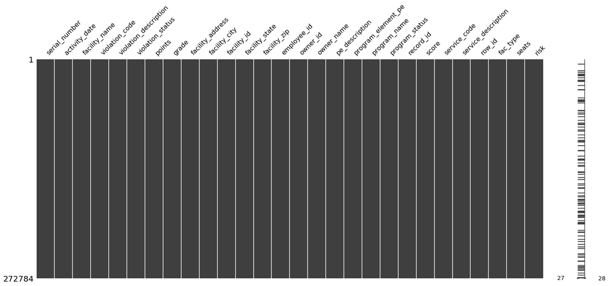

```python
import missingno as msno
msno.matrix(df_violate)
```

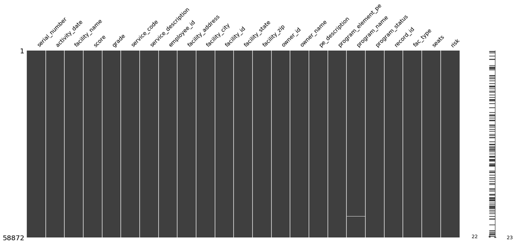

```python
import missingno as msno
msno.matrix(df_inspect) #visulizing the missing value:
```

zipcode extensions When looking at the zipcode, we noticed that some of the zipcode records have extensions for better mailing purpose. To have a deeper understanding of the data,we only take the first five characters.

```python
def clean_zip(x):
    return x[:5]
df_inspect['facility_zip'] = df_inspect['facility_zip'].apply(clean_zip)
df_violate['facility_zip'] = df_violate['facility_zip'].apply(clean_zip)
#df_inspect['facility_zip'].head()
#df_violate['facility_zip'].head()
```

Reshape dataframe

Step1: group a new data frame by facility and violation code, then aggregate by the count to find the total times each facility has violated a particular rule.

```python
vio_grouped = df_violate.groupby(['facility_id','violation_code'])
vio_counts = vio_grouped.agg({
    'violation_code': 'count'
})
vio_counts.head()
```

| facility_id | violation_code | violation_code |
| --- | --- | --- |
| FA0000968 | F006 | 1 |
|  | F029 | 2 |
|  | F033 | 3 |
|  | F035 | 1 |
|  | F036 | 3 |

step2: transpose violation codes into columns

```python
vio_matrix = vio_counts['violation_code'].unstack(0).T #rows to columns
vio_matrix.fillna(0, inplace=True)
vio_matrix.reset_index(inplace=True)
vio_matrix.head()
```

| violation_code | facility_id | F001 | F002 | F003 | F004 | F005 | F006 | F007 | F008 | F009 | ... | W019 | W021 | W023 | W027 | W028 | W032 | W034 | W044 | W051 | W052 |
| --- | --- | --- | --- | --- | --- | --- | --- | --- | --- | --- | --- | --- | --- | --- | --- | --- | --- | --- | --- | --- | --- |
| 0 | FA0000968 | 0.0 | 0.0 | 0.0 | 0.0 | 0.0 | 1.0 | 0.0 | 0.0 | 0.0 | ... | 0.0 | 0.0 | 0.0 | 0.0 | 0.0 | 0.0 | 0.0 | 0.0 | 0.0 | 0.0 |
| 1 | FA0000999 | 0.0 | 0.0 | 0.0 | 0.0 | 0.0 | 0.0 | 0.0 | 0.0 | 0.0 | ... | 0.0 | 0.0 | 0.0 | 0.0 | 0.0 | 0.0 | 0.0 | 0.0 | 0.0 | 0.0 |
| 2 | FA0001155 | 0.0 | 0.0 | 0.0 | 0.0 | 0.0 | 0.0 | 0.0 | 0.0 | 0.0 | ... | 0.0 | 0.0 | 0.0 | 0.0 | 0.0 | 0.0 | 0.0 | 0.0 | 0.0 | 0.0 |
| 3 | FA0001320 | 0.0 | 0.0 | 0.0 | 0.0 | 0.0 | 1.0 | 5.0 | 0.0 | 0.0 | ... | 0.0 | 0.0 | 0.0 | 0.0 | 0.0 | 0.0 | 0.0 | 0.0 | 0.0 | 0.0 |
| 4 | FA0001404 | 0.0 | 0.0 | 0.0 | 0.0 | 0.0 | 2.0 | 0.0 | 0.0 | 0.0 | ... | 0.0 | 0.0 | 0.0 | 0.0 | 0.0 | 0.0 | 0.0 | 0.0 | 0.0 | 0.0 |

5 rows × 71 columns

```python
import pandas as pd
inspect_vio_df = pd.merge(df_inspect, vio_matrix, on='facility_id', how='left') #merge
inspect_vio_df.fillna(0, inplace = True)
inspect_vio_df['facility_zip'] = inspect_vio_df['facility_zip'].apply(clean_zip)
inspect_vio_df.head()
```

|  | serial_number | activity_date | facility_name | score | grade | service_code | service_description | employee_id | facility_address | facility_city | ... | W019 | W021 | W023 | W027 | W028 | W032 | W034 | W044 | W051 | W052 |
| --- | --- | --- | --- | --- | --- | --- | --- | --- | --- | --- | --- | --- | --- | --- | --- | --- | --- | --- | --- | --- | --- |
| 0 | DAJ00E07B | 2017-12-29 | HABITAT COFFEE SHOP | 95 | A | 1 | ROUTINE INSPECTION | EE0000923 | 3708 N EAGLE ROCK BLVD | LOS ANGELES | ... | 0.0 | 0.0 | 0.0 | 0.0 | 0.0 | 0.0 | 0.0 | 0.0 | 0.0 | 0.0 |
| 1 | DAQOKRFZB | 2017-12-29 | REILLY'S | 92 | A | 1 | ROUTINE INSPECTION | EE0000633 | 100 WORLD WAY # 120 | LOS ANGELES | ... | 0.0 | 0.0 | 0.0 | 0.0 | 0.0 | 0.0 | 0.0 | 0.0 | 0.0 | 0.0 |
| 2 | DASJI4LUR | 2017-12-29 | STREET CHURROS | 93 | A | 1 | ROUTINE INSPECTION | EE0000835 | 6801 HOLLYWOOD BLVD # 253 | LOS ANGELES | ... | 0.0 | 0.0 | 0.0 | 0.0 | 0.0 | 0.0 | 0.0 | 0.0 | 0.0 | 0.0 |
| 3 | DAWVA0CY3 | 2017-12-29 | RIO GENTLEMANS CLUB | 93 | A | 1 | ROUTINE INSPECTION | EE0000958 | 13124 S FIGUEROA ST | LOS ANGELES | ... | 0.0 | 0.0 | 0.0 | 0.0 | 0.0 | 0.0 | 0.0 | 0.0 | 0.0 | 0.0 |
| 4 | DAKFCHD0L | 2017-12-29 | LE PAIN QUOTIDIEN | 93 | A | 1 | ROUTINE INSPECTION | EE0000629 | 13050 SAN VICENTE BLVD STE 114 | LOS ANGELES | ... | 0.0 | 0.0 | 0.0 | 0.0 | 0.0 | 0.0 | 0.0 | 0.0 | 0.0 | 0.0 |

5 rows × 93 columns

## Correlation Analysis

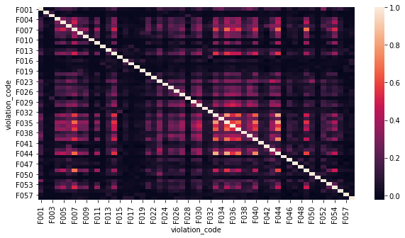

```python
plt.figure(figsize=(10,5))
sns.heatmap(vio_matrix.corr())
```

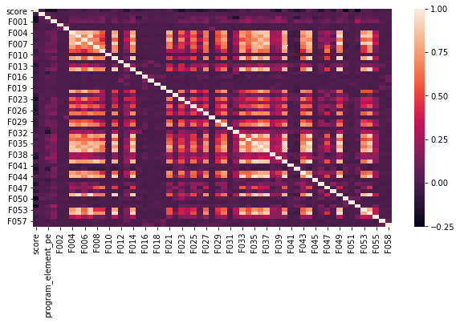

```python
plt.figure(figsize=(10,5))
sns.heatmap(inspect_vio_df.corr())
```

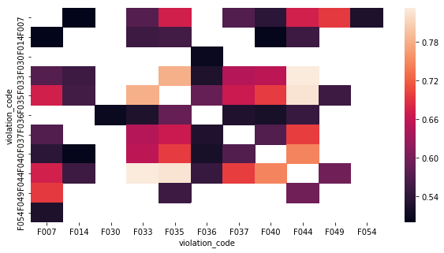

```python
corr = vio_matrix.corr()
mask = (corr > 0.5) & (corr != 1.0)
masked = corr[mask]
masked.dropna(how='all', axis = 0, inplace=True)
masked.dropna(how='all', axis = 1, inplace=True)
plt.figure(figsize=(10,5))
sns.heatmap(masked)
```

Matching violation codes with violation descriptions

```python
vio_codes = list(df_violate['violation_code'].unique())
vio_descs = list(df_violate['violation_description'].unique())
```

```python
violation_dict = dict.fromkeys(vio_codes) #matching
for x in violation_dict:
    for desc in vio_descs:
        if x[-2:] == desc[2:4]:
            violation_dict[x] = desc
violation_dict
```

```
{'F030': '# 30. Food properly stored; food storage containers identified',
 'F027': '# 27. Food separated and protected',
 'F035': '# 35. Equipment/Utensils - approved; installed; clean; good repair, capacity',
 'F033': '# 33. Nonfood-contact surfaces clean and in good repair',
 'F029': '# 29. Toxic substances properly identified, stored, used',
 'F044': '# 44. Floors, walls and ceilings: properly built, maintained in good repair and clean',
 'F006': '# 06. Adequate handwashing facilities supplied & accessible',
 'F039': '# 39. Wiping cloths: properly used and stored',
 'F037': '# 37. Adequate ventilation and lighting; designated areas, use',
 'F032': '# 32. Food properly labeled & honestly presented',
 'F034': '# 34. Warewashing facilities: Adequate, maintained, properly use, test strips available',
 'F014': '# 14. Food contact surfaces: clean and sanitized',
 'F043': '# 43. Premises; personal/cleaning items; vermin-proofing',
 'F042': '# 42. Toilet facilities: properly constructed, supplied, cleaned',
 'F009': '# 09. Proper cooling methods',
 'F007': '# 07. Proper hot and cold holding temperatures',
 'F036': '# 36. Equipment, utensils and linens: storage and use',
 'F038': '# 38. Thermometers provided and accurate',
 'F048': '# 48. Plan Review required for new or remodel construction',
 'F040': '# 40. Plumbing: Plumbing in good repair, proper backflow devices',
 'F049': '# 49. Samples Collected',
 'F046': '# 46. Signs posted; last inspection report available',
 'F023': '# 23. No rodents, insects, birds, or animals',
 'F055': None,
 'F013': '# 13. Food in good condition, safe and unadulterated',
 'F025': '# 25. Personal cleanliness and hair restraints',
 'F053': None,
 'F041': '# 41. Garbage and refuse properly disposed; facilities maintained',
 'F052': '# 52. Multiple Major Critical Violations / Increased Risk to Public Health',
 'F054': None,
 'F024': '# 24. Person in charge present and performs duties',
 'F026': '# 26. Approved thawing methods used, frozen food maintained frozen',
 'F028': '# 28. Fruits and vegetables washed as required',
 'F050': '# 50. Impoundment of unsanitary equipment or food',
 'F008': '# 08. Time as a public health control; procedures & records',
 'F016': '# 16. Compliance with shelf stock tags, condition, displayed',
 'F058': None,
 'F005': '# 05. Hands clean and properly washed; gloves used properly',
 'F045': '# 45. Sleeping quarters',
 'F004': '# 04. Proper eating, drinking, or tobacco use',
 'F047': '# 47. Permits Available',
 'F011': '# 11. Proper reheating procedures for hot holding',
 'F022': '# 22. Sewage and wastewater properly disposed',
 'F051': '# 51. Permit Suspension',
 'F015': '# 15. Food obtained from approved source',
 'F031': '# 31. Consumer self service facilities properly constructed and maintained',
 'F057': None,
 'F021': '# 21b. Water available',
 'F002': '# 02. Communicable disease; reporting, restrictions & exclusions',
 'F012': '# 12. Returned and reservice food',
 'F003': '# 03. No discharge from eyes, nose, and mouth',
 'F017': '# 17. Compliance with Gulf Oyster Regulations',
 'F001': '# 01b. Food safety certification',
 'F019': '# 19. Consumer advisory provided for raw or undercooked foods',
 'F018': '# 18. Compliance with variance, specialized process, & HACCP Plan',
 'F010': '# 10. Proper cooking time & temperatures'}
```

## Georgraphical distribution

```python
geo_group = inspect_vio_df.groupby('facility_zip') #grouping and aggregating
geo_agg = geo_group.agg({'score': np.mean,
                       'facility_id': pd.Series.nunique,
                        })
geo_agg.rename(columns = {'score':'average_score','facility_id':'total_facilities'}, inplace = True)
geo_agg.reset_index(inplace=True)
```

```python
geo_agg
```

|  | facility_zip | average_score | total_facilities |
| --- | --- | --- | --- |
| 0 | 90001 | 93.987292 | 276 |
| 1 | 90002 | 94.570175 | 69 |
| 2 | 90003 | 92.843198 | 276 |
| 3 | 90004 | 92.673001 | 277 |
| 4 | 90005 | 91.307221 | 302 |
| 5 | 90006 | 92.586446 | 431 |
| 6 | 90007 | 94.790235 | 252 |
| 7 | 90008 | 94.182670 | 96 |
| 8 | 90010 | 92.301523 | 202 |
| 9 | 90011 | 93.330645 | 340 |
| 10 | 90012 | 93.395563 | 465 |
| 11 | 90013 | 94.455628 | 242 |
| 12 | 90014 | 94.178451 | 247 |
| 13 | 90015 | 94.111520 | 341 |
| 14 | 90016 | 93.355649 | 147 |
| 15 | 90017 | 93.752778 | 269 |
| 16 | 90018 | 93.990826 | 127 |
| 17 | 90019 | 92.463592 | 268 |
| 18 | 90020 | 91.051108 | 332 |
| 19 | 90021 | 94.176955 | 137 |
| 20 | 90022 | 92.559626 | 299 |
| 21 | 90023 | 93.458726 | 227 |
| 22 | 90024 | 92.427663 | 226 |
| 23 | 90025 | 93.453883 | 316 |
| 24 | 90026 | 93.206226 | 296 |
| 25 | 90027 | 93.607079 | 313 |
| 26 | 90028 | 93.611279 | 507 |
| 27 | 90029 | 93.000808 | 276 |
| 28 | 90030 | 91.111111 | 1 |
| 29 | 90031 | 93.580786 | 118 |
| ... | ... | ... | ... |
| 67 | 90077 | 93.592593 | 23 |
| 68 | 90079 | 94.173913 | 5 |
| 69 | 90089 | 97.000000 | 33 |
| 70 | 90094 | 94.119048 | 11 |
| 71 | 90095 | 95.923077 | 6 |
| 72 | 90103 | 90.333333 | 1 |
| 73 | 90201 | 98.000000 | 1 |
| 74 | 90211 | 91.285714 | 1 |
| 75 | 90220 | 97.625000 | 1 |
| 76 | 90222 | 98.500000 | 1 |
| 77 | 90230 | 93.882353 | 3 |
| 78 | 90232 | 94.666667 | 3 |
| 79 | 90272 | 94.166667 | 1 |
| 80 | 90291 | 92.450704 | 15 |
| 81 | 90292 | 92.666667 | 1 |
| 82 | 90293 | 92.166667 | 1 |
| 83 | 90723 | 91.500000 | 1 |
| 84 | 90921 | 92.250000 | 1 |
| 85 | 91006 | 95.500000 | 1 |
| 86 | 91307 | 99.000000 | 1 |
| 87 | 91324 | 92.666667 | 1 |
| 88 | 91325 | 94.857143 | 1 |
| 89 | 91326 | 98.000000 | 1 |
| 90 | 91340 | 96.000000 | 1 |
| 91 | 91367 | 94.400000 | 1 |
| 92 | 91505 | 99.000000 | 1 |
| 93 | 91601 | 95.000000 | 1 |
| 94 | 91602 | 95.000000 | 1 |
| 95 | 91604 | 93.791667 | 3 |
| 96 | 92880 | 96.500000 | 1 |

97 rows × 3 columns

Find data that represents the boundary of each zipcode area Data source: http://boundaries.latimes.com/set/zip-code-tabulation-areas-2012/

```python
# load GeoJSON
import simplejson as json
with open('/Users/zhangdoudou/Desktop/BD_Project/la-zip-code-areas-2012.geojson', 'r') as jsonFile:
    data = json.load(jsonFile)
tmp = data

# remove ZIP codes not in our dataset
geozips = []
for i in range(len(tmp['features'])):
    if tmp['features'][i]['properties']['name'] in list(geo_agg['facility_zip'].unique()):
        geozips.append(tmp['features'][i])

# creating new JSON object
new_json = dict.fromkeys(['type','features'])
new_json['type'] = 'FeatureCollection'
new_json['features'] = geozips

# save JSON object as updated-file
open("updated-file.json", "w").write(
    json.dumps(new_json, sort_keys=True, indent=4, separators=(',', ': '))
)
```

```
1160874
```

```python
import folium

# table = main table/data frame we read from (pandas DataFrame)
# zips = column name where ZIP codes are (string)
# mapped_feature = column name for feature we want to visualize (string)
# add_text = any additional commentary to be added in the map legend (string)

def create_map(table, zips, mapped_feature, add_text = ''):
    # reading of the updated GeoJSON file
    la_geo = r'updated-file.json'
    # initiating a Folium map with LA's longitude and latitude
    m = folium.Map(location = [34.0522, -118.2437], zoom_start = 11)
    # creating a choropleth map
    m.choropleth(
        geo_data = la_geo,
        fill_opacity = 0.7,
        line_opacity = 0.2,
        data = table,
        # refers to which key within the GeoJSON to map the ZIP code to
        key_on = 'feature.properties.name',
        # first element contains location information, second element contains feature of interest
        columns = [zips, mapped_feature],
        fill_color = 'RdYlGn',
        legend_name = (' ').join(mapped_feature.split('_')).title() + ' ' + add_text + ' Across LA'
    )
    folium.LayerControl().add_to(m)
    # save map with filename based on the feature of interest
    m.save(outfile = mapped_feature + '_map.html')
```

Score distribution

```python
create_map(geo_agg, 'facility_zip', 'average_score', 'of Facilities')
```

```python
Facility ditribution
```

```python
create_map(geo_agg, 'facility_zip', 'total_facilities')
```

violation distribution

```python
fac_grouped = inspect_vio_df.groupby(['facility_zip','facility_id'])
fac_agg = fac_grouped.agg({'F044': np.mean,
                        'F033': np.mean,
                        'F035': np.mean,
                        'F036': np.mean,
                        'F040': np.mean,
                        'F043': np.mean,
                        'F037': np.mean,
                        'F039': np.mean,
                        'F030': np.mean,
                        'F006': np.mean,
                        'F014': np.mean,
                        'F007': np.mean})
```

```python
fac_agg = fac_agg.groupby(level=0).mean()
fac_agg.reset_index(inplace=True)
```

```python
create_map(fac_agg, 'facility_zip', 'F044', 'Average Violation of Floor, Walls, and Ceiling Maintenance and Condition')
create_map(fac_agg, 'facility_zip', 'F033', 'Average Violation of Nonfood Equipment Cleanliness and Maintenance')
create_map(fac_agg, 'facility_zip', 'F035', 'Average Violation of Equiptment/Utensils Cleanliness and Maintenance')
create_map(fac_agg, 'facility_zip', 'F036', 'Average Violation of Equiptment/Utensils/Linens Storage and Use')
create_map(fac_agg, 'facility_zip', 'F040', 'Average Violation of Plumbing')
create_map(fac_agg, 'facility_zip', 'F014', 'Average Violation of Surface Cleaning and Sanitization')
```

```python
inspect_vio_df.dtypes
```

```
serial_number                  object
activity_date          datetime64[ns]
facility_name                  object
score                           int64
grade                          object
service_code                    int64
service_description            object
employee_id                    object
facility_address               object
facility_city                  object
facility_id                    object
facility_state                 object
facility_zip                   object
owner_id                       object
owner_name                     object
pe_description                 object
program_element_pe              int64
program_name                   object
program_status                 object
record_id                      object
fac_type                       object
seats                          object
risk                           object
F001                          float64
F002                          float64
F003                          float64
F004                          float64
F005                          float64
F006                          float64
F007                          float64
                            ...
F042                          float64
F043                          float64
F044                          float64
F045                          float64
F046                          float64
F047                          float64
F048                          float64
F049                          float64
F050                          float64
F051                          float64
F052                          float64
F053                          float64
F054                          float64
F055                          float64
F056                          float64
F057                          float64
F058                          float64
H102                          float64
W004                          float64
W005                          float64
W019                          float64
W021                          float64
W023                          float64
W027                          float64
W028                          float64
W032                          float64
W034                          float64
W044                          float64
W051                          float64
W052                          float64
Length: 93, dtype: object
```

## Modeling

objective: grade features: risk level, facility type, service code, month, day

### Feature Engineering

Split date to year, month and the day of the week(Mon,Tue,Wed...)

```python
df_inspect2 = pd.read_csv('/Users/zhangdoudou/Desktop/BD_Project/restaurant-and-market-health-inspections.csv')
```

```python
def clean_date(x):
    return x[:10]

date = df_inspect2['activity_date'].astype('str').apply(clean_date)
```

```python
inspect_vio_df['month'] = pd.to_datetime(date).dt.month #find month
inspect_vio_df['day'] = pd.to_datetime(date).dt.dayofweek #find day of the week
inspect_vio_df['year'] = pd.to_datetime(date).dt.year #year
```

```python
inspect_vio_df.dtypes
```

```
serial_number                  object
activity_date          datetime64[ns]
facility_name                  object
score                           int64
grade                          object
service_code                    int64
service_description            object
employee_id                    object
facility_address               object
facility_city                  object
facility_id                    object
facility_state                 object
facility_zip                   object
owner_id                       object
owner_name                     object
pe_description                 object
program_element_pe              int64
program_name                   object
program_status                 object
record_id                      object
fac_type                       object
seats                          object
risk                           object
F001                          float64
F002                          float64
F003                          float64
F004                          float64
F005                          float64
F006                          float64
F007                          float64
                            ...
F031                          float64
F032                          float64
F033                          float64
F034                          float64
F035                          float64
F036                          float64
F037                          float64
F038                          float64
F039                          float64
F040                          float64
F041                          float64
F042                          float64
F043                          float64
F044                          float64
F045                          float64
F046                          float64
F047                          float64
F048                          float64
F049                          float64
F050                          float64
F051                          float64
F052                          float64
F053                          float64
F054                          float64
F055                          float64
F057                          float64
F058                          float64
month                           int64
day                             int64
year                            int64
Length: 82, dtype: object
```

```python
code_count = df_violate.violation_code.value_counts()
code_count
```

```
F044    30289
F033    28426
F035    23596
F036    15214
F040    14865
F043    14711
F037    12852
F039    12138
F030    11368
F006    10874
F014    10542
F007    10307
F023     9855
F034     6054
F029     5825
F052     5811
F027     5348
F042     5089
F046     4697
F025     3781
F038     3393
F001     3308
F009     2379
F026     2298
F032     2078
F049     1932
F021     1658
F048     1587
F013     1576
F041     1380
F005     1306
F053     1292
F008     1262
F004     1007
F050      985
F055      930
F054      402
F022      399
F024      302
F016      279
F015      264
F031      209
F047      206
F045      165
F011      162
F058       97
F019       70
F028       68
F018       66
F057       19
F010       14
F051       12
F003       11
F017       10
F012       10
F002        6
Name: violation_code, dtype: int64
```

```python
 def is_large(x):
    if x == 'F044' or x == 'F033' or x == 'F035' or x == 'F036' or x == 'F040' or x == 'F043' or x == 'F037' or x == 'F039' or x == 'F030' or x == 'F006' or x == 'F004' or x == 'F014' or x == 'F023':
     return 1
    return 0

inspect_vio_df['code_islarge'] = df_violate.violation_code.apply(is_large)
inspect_vio_df.head()
#df_violate.violation_code.apply(is_large)
```

|  | serial_number | activity_date | facility_name | score | grade | service_code | service_description | employee_id | facility_address | facility_city | ... | W028 | W032 | W034 | W044 | W051 | W052 | month | day | year | code_islarge |
| --- | --- | --- | --- | --- | --- | --- | --- | --- | --- | --- | --- | --- | --- | --- | --- | --- | --- | --- | --- | --- | --- |
| 0 | DAJ00E07B | 2017-12-29 | HABITAT COFFEE SHOP | 95 | 1 | 1 | ROUTINE INSPECTION | EE0000923 | 3708 N EAGLE ROCK BLVD | LOS ANGELES | ... | 0.0 | 0.0 | 0.0 | 0.0 | 0.0 | 0.0 | 12 | 4 | 2017 | 1 |
| 1 | DAQOKRFZB | 2017-12-29 | REILLY'S | 92 | 1 | 1 | ROUTINE INSPECTION | EE0000633 | 100 WORLD WAY # 120 | LOS ANGELES | ... | 0.0 | 0.0 | 0.0 | 0.0 | 0.0 | 0.0 | 12 | 4 | 2017 | 0 |
| 2 | DASJI4LUR | 2017-12-29 | STREET CHURROS | 93 | 1 | 1 | ROUTINE INSPECTION | EE0000835 | 6801 HOLLYWOOD BLVD # 253 | LOS ANGELES | ... | 0.0 | 0.0 | 0.0 | 0.0 | 0.0 | 0.0 | 12 | 4 | 2017 | 1 |
| 3 | DAWVA0CY3 | 2017-12-29 | RIO GENTLEMANS CLUB | 93 | 1 | 1 | ROUTINE INSPECTION | EE0000958 | 13124 S FIGUEROA ST | LOS ANGELES | ... | 0.0 | 0.0 | 0.0 | 0.0 | 0.0 | 0.0 | 12 | 4 | 2017 | 1 |
| 4 | DAKFCHD0L | 2017-12-29 | LE PAIN QUOTIDIEN | 93 | 1 | 1 | ROUTINE INSPECTION | EE0000629 | 13050 SAN VICENTE BLVD STE 114 | LOS ANGELES | ... | 0.0 | 0.0 | 0.0 | 0.0 | 0.0 | 0.0 | 12 | 4 | 2017 | 0 |

5 rows × 97 columns

Feature: service code

```python
def is_routine(x):
    if x == 1:
     return 1
    return 0

inspect_vio_df['service_code'] = inspect_vio_df.service_code.apply(is_routine)
```

```python
def is_A(x):
    if x == 'A':
     return 1
    return 0

inspect_vio_df['grade'] = inspect_vio_df.grade.apply(is_A)
```

Extract Features and target from the large dataset

```python
columns = ['fac_type', 'risk','service_code','grade','month','day','year','code_islarge','score']
model_data = inspect_vio_df[columns]
model_data = model_data.dropna()
model_data.head()
```

|  | fac_type | risk | service_code | grade | month | day | year | code_islarge | score |
| --- | --- | --- | --- | --- | --- | --- | --- | --- | --- |
| 0 | RESTAURANT | MODERATE RISK | 1 | 1 | 12 | 4 | 2017 | 1 | 95 |
| 1 | RESTAURANT | MODERATE RISK | 1 | 1 | 12 | 4 | 2017 | 0 | 92 |
| 2 | RESTAURANT | LOW RISK | 1 | 1 | 12 | 4 | 2017 | 1 | 93 |
| 3 | RESTAURANT | LOW RISK | 1 | 1 | 12 | 4 | 2017 | 1 | 93 |
| 4 | RESTAURANT | HIGH RISK | 1 | 1 | 12 | 4 | 2017 | 0 | 93 |

```python
# Initialize H2O cluster
import h2o
h2o.init()
```

[output not shown]

| H2O cluster uptime: | 03 secs |
| --- | --- |
| H2O cluster timezone: | America/New_York |
| H2O data parsing timezone: | UTC |
| H2O cluster version: | 3.24.0.3 |
| H2O cluster version age: | 5 days |
| H2O cluster name: | H2O_from_python_zhangdoudou_x5iijf |
| H2O cluster total nodes: | 1 |
| H2O cluster free memory: | 1.778 Gb |
| H2O cluster total cores: | 4 |
| H2O cluster allowed cores: | 4 |
| H2O cluster status: | accepting new members, healthy |
| H2O connection url: | http://127.0.0.1:54321 |
| H2O connection proxy: | None |
| H2O internal security: | False |
| H2O API Extensions: | AutoML, Amazon S3, XGBoost, Algos, Core V3, Core V4 |
| Python version: | 3.7.1 final |

```python
#model data summary
model_data = H2OFrame(model_data)

for name in ['fac_type', 'risk','service_code','grade','month','day','year','code_islarge']:
    model_data[name] = model_data[name].asfactor()

model_data.summary()
```

```
Parse progress: |█████████████████████████████████████████████████████████| 100%
```

|  | fac_type | risk | service_code | grade | month | day | year | code_islarge | score |
| --- | --- | --- | --- | --- | --- | --- | --- | --- | --- |
| type | enum | enum | enum | enum | enum | enum | enum | enum | int |
| mins |  |  |  |  |  |  |  |  | 64.0 |
| mean |  |  |  |  |  |  |  |  | 93.30792227204715 |
| maxs |  |  |  |  |  |  |  |  | 100.0 |
| sigma |  |  |  |  |  |  |  |  | 3.9967117691899703 |
| zeros |  |  |  |  |  |  |  |  | 0 |
| missing | 0 | 0 | 0 | 0 | 0 | 0 | 0 | 0 | 0 |
| 0 | RESTAURANT | MODERATE RISK | 1 | 1 | 12 | 4 | 2017 | 1 | 95.0 |
| 1 | RESTAURANT | MODERATE RISK | 1 | 1 | 12 | 4 | 2017 | 0 | 92.0 |
| 2 | RESTAURANT | LOW RISK | 1 | 1 | 12 | 4 | 2017 | 1 | 93.0 |
| 3 | RESTAURANT | LOW RISK | 1 | 1 | 12 | 4 | 2017 | 1 | 93.0 |
| 4 | RESTAURANT | HIGH RISK | 1 | 1 | 12 | 4 | 2017 | 0 | 93.0 |
| 5 | RESTAURANT | MODERATE RISK | 1 | 1 | 12 | 4 | 2017 | 1 | 94.0 |
| 6 | FOOD MKT RETAIL | LOW RISK | 1 | 1 | 12 | 4 | 2017 | 1 | 96.0 |
| 7 | RESTAURANT | MODERATE RISK | 1 | 1 | 12 | 4 | 2017 | 1 | 94.0 |
| 8 | RESTAURANT | HIGH RISK | 1 | 1 | 12 | 4 | 2017 | 1 | 93.0 |
| 9 | FOOD MKT RETAIL | LOW RISK | 1 | 1 | 12 | 4 | 2017 | 1 | 95.0 |

```python
# Split into 70% training and 30% test dataset
strat_split = model_data['score'].stratified_split(test_frac=0.3, seed=42)
#train, test, valid = model_data.split_frame([0.6, 0.2]) #0.6,0.2,0.2
train = model_data[strat_split == 'train']
test = model_data[strat_split == 'test']

# Define features and target
feature = ['fac_type', 'risk','service_code','month','day','year','code_islarge']
target = 'grade'
```

```python
#gradient boosting machine(GBM)
from h2o.estimators.gbm import H2OGradientBoostingEstimator
model_gbm = H2OGradientBoostingEstimator(distribution="multinomial",
          ntrees=100, max_depth=3, min_rows=2, learn_rate=0.2,seed=42)
model_gbm.train(x=feature, y=target, training_frame=train, validation_frame=test)
```

```
gbm Model Build progress: |███████████████████████████████████████████████| 100%
```

```python
model_gbm.score_history()
```

|  |  | timestamp | duration | number_of_trees | training_rmse | training_logloss | training_auc | training_pr_auc | training_lift | training_classification_error | validation_rmse | validation_logloss | validation_auc | validation_pr_auc | validation_lift | validation_classification_error |
| --- | --- | --- | --- | --- | --- | --- | --- | --- | --- | --- | --- | --- | --- | --- | --- | --- |
| 0 |  | 2019-05-11 19:24:01 | 0.010 sec | 0.0 | 0.250662 | 0.246783 | 0.500000 | 0.000000 | 1.000000 | 0.067370 | 0.250868 | 0.247096 | 0.500000 | 0.000000 | 1.000000 | 0.067490 |
| 1 |  | 2019-05-11 19:24:01 | 0.049 sec | 1.0 | 0.250068 | 0.244400 | 0.630102 | 0.842860 | 1.052995 | 0.067370 | 0.250434 | 0.245322 | 0.598867 | 0.835111 | 1.050521 | 0.067490 |
| 2 |  | 2019-05-11 19:24:01 | 0.078 sec | 2.0 | 0.249679 | 0.242808 | 0.635464 | 0.895139 | 1.055857 | 0.067370 | 0.250117 | 0.243960 | 0.608352 | 0.891196 | 1.059769 | 0.067490 |
| 3 |  | 2019-05-11 19:24:01 | 0.107 sec | 3.0 | 0.249408 | 0.241660 | 0.635785 | 0.915095 | 1.054600 | 0.067370 | 0.249960 | 0.243211 | 0.606164 | 0.912556 | 1.063632 | 0.067490 |
| 4 |  | 2019-05-11 19:24:01 | 0.136 sec | 4.0 | 0.249220 | 0.240836 | 0.637232 | 0.915122 | 1.054600 | 0.067370 | 0.249825 | 0.242558 | 0.610054 | 0.912844 | 1.063632 | 0.067490 |
| 5 |  | 2019-05-11 19:24:01 | 0.167 sec | 5.0 | 0.249093 | 0.240259 | 0.639351 | 0.948768 | 1.052653 | 0.067370 | 0.249730 | 0.242093 | 0.613168 | 0.945328 | 1.055352 | 0.067490 |
| 6 |  | 2019-05-11 19:24:01 | 0.201 sec | 6.0 | 0.248995 | 0.239809 | 0.639538 | 0.957846 | 1.057769 | 0.067370 | 0.249703 | 0.241887 | 0.612255 | 0.954936 | 1.053885 | 0.067490 |
| 7 |  | 2019-05-11 19:24:01 | 0.241 sec | 7.0 | 0.248921 | 0.239469 | 0.641035 | 0.957937 | 1.056127 | 0.067370 | 0.249676 | 0.241693 | 0.613808 | 0.955330 | 1.056308 | 0.067490 |
| 8 |  | 2019-05-11 19:24:01 | 0.274 sec | 8.0 | 0.248869 | 0.239237 | 0.641761 | 0.960096 | 1.059593 | 0.067370 | 0.249666 | 0.241611 | 0.614039 | 0.956853 | 1.066349 | 0.067490 |
| 9 |  | 2019-05-11 19:24:01 | 0.309 sec | 9.0 | 0.248823 | 0.239020 | 0.643385 | 0.960206 | 1.059344 | 0.067370 | 0.249658 | 0.241542 | 0.613455 | 0.956926 | 1.067231 | 0.067490 |
| 10 |  | 2019-05-11 19:24:01 | 0.345 sec | 10.0 | 0.248787 | 0.238864 | 0.643853 | 0.960234 | 1.058664 | 0.067370 | 0.249655 | 0.241509 | 0.614309 | 0.956977 | 1.066958 | 0.067490 |
| 11 |  | 2019-05-11 19:24:01 | 0.388 sec | 11.0 | 0.248758 | 0.238700 | 0.644219 | 0.960563 | 1.056772 | 0.067370 | 0.249649 | 0.241452 | 0.615045 | 0.956887 | 1.060325 | 0.067490 |
| 12 |  | 2019-05-11 19:24:01 | 0.426 sec | 12.0 | 0.248727 | 0.238576 | 0.645179 | 0.960833 | 1.064817 | 0.067370 | 0.249645 | 0.241416 | 0.615174 | 0.956912 | 1.063208 | 0.067490 |
| 13 |  | 2019-05-11 19:24:01 | 0.471 sec | 13.0 | 0.248703 | 0.238471 | 0.645325 | 0.960870 | 1.062769 | 0.067370 | 0.249668 | 0.241476 | 0.615191 | 0.956861 | 1.060843 | 0.067490 |
| 14 |  | 2019-05-11 19:24:01 | 0.516 sec | 14.0 | 0.248681 | 0.238379 | 0.645606 | 0.960932 | 1.062145 | 0.067370 | 0.249659 | 0.241431 | 0.615486 | 0.956782 | 1.060325 | 0.067490 |
| 15 |  | 2019-05-11 19:24:01 | 0.562 sec | 15.0 | 0.248640 | 0.238233 | 0.646470 | 0.961134 | 1.067905 | 0.067346 | 0.249655 | 0.241406 | 0.615379 | 0.956687 | 1.060257 | 0.067490 |
| 16 |  | 2019-05-11 19:24:02 | 0.618 sec | 16.0 | 0.248615 | 0.238123 | 0.647285 | 0.961273 | 1.069726 | 0.067346 | 0.249657 | 0.241431 | 0.614898 | 0.956687 | 1.066514 | 0.067490 |
| 17 |  | 2019-05-11 19:24:02 | 0.679 sec | 17.0 | 0.248599 | 0.238032 | 0.647481 | 0.961318 | 1.062050 | 0.067346 | 0.249673 | 0.241466 | 0.614843 | 0.956555 | 1.060718 | 0.067490 |
| 18 |  | 2019-05-11 19:24:02 | 0.743 sec | 18.0 | 0.248559 | 0.237906 | 0.648574 | 0.961446 | 1.062098 | 0.067346 | 0.249648 | 0.241383 | 0.615524 | 0.956679 | 1.060718 | 0.067490 |
| 19 |  | 2019-05-11 19:24:02 | 0.803 sec | 19.0 | 0.248532 | 0.237821 | 0.649002 | 0.961515 | 1.064448 | 0.067346 | 0.249644 | 0.241379 | 0.615522 | 0.956622 | 1.060966 | 0.067490 |
| 20 |  | 2019-05-11 19:24:02 | 0.867 sec | 20.0 | 0.248512 | 0.237745 | 0.649702 | 0.961547 | 1.061902 | 0.067346 | 0.249640 | 0.241364 | 0.615651 | 0.956650 | 1.060257 | 0.067490 |
| 21 |  | 2019-05-11 19:24:02 | 0.938 sec | 21.0 | 0.248493 | 0.237688 | 0.650361 | 0.961639 | 1.063208 | 0.067346 | 0.249656 | 0.241408 | 0.615043 | 0.956615 | 1.060257 | 0.067490 |
| 22 |  | 2019-05-11 19:24:02 | 0.998 sec | 22.0 | 0.248478 | 0.237626 | 0.650752 | 0.961713 | 1.063227 | 0.067346 | 0.249621 | 0.241329 | 0.615325 | 0.956658 | 1.055442 | 0.067433 |
| 23 |  | 2019-05-11 19:24:02 | 1.050 sec | 23.0 | 0.248457 | 0.237551 | 0.651292 | 0.961791 | 1.064523 | 0.067346 | 0.249625 | 0.241334 | 0.615655 | 0.956689 | 1.060257 | 0.067433 |
| 24 |  | 2019-05-11 19:24:02 | 1.097 sec | 24.0 | 0.248442 | 0.237495 | 0.651677 | 0.961865 | 1.064467 | 0.067346 | 0.249629 | 0.241353 | 0.615769 | 0.956699 | 1.060325 | 0.067433 |
| 25 |  | 2019-05-11 19:24:02 | 1.145 sec | 25.0 | 0.248427 | 0.237449 | 0.652005 | 0.961915 | 1.064467 | 0.067346 | 0.249623 | 0.241326 | 0.615984 | 0.956752 | 1.060459 | 0.067433 |
| 26 |  | 2019-05-11 19:24:02 | 1.193 sec | 26.0 | 0.248423 | 0.237435 | 0.652017 | 0.961811 | 1.064808 | 0.067346 | 0.249620 | 0.241310 | 0.616107 | 0.956785 | 1.060459 | 0.067433 |
| 27 |  | 2019-05-11 19:24:02 | 1.232 sec | 27.0 | 0.248423 | 0.237435 | 0.652017 | 0.961811 | 1.064808 | 0.067346 | 0.249620 | 0.241310 | 0.616107 | 0.956785 | 1.060459 | 0.067433 |
| 28 |  | 2019-05-11 19:24:02 | 1.271 sec | 28.0 | 0.248423 | 0.237435 | 0.652017 | 0.961811 | 1.064808 | 0.067346 | 0.249620 | 0.241310 | 0.616107 | 0.956785 | 1.060459 | 0.067433 |
| 29 |  | 2019-05-11 19:24:02 | 1.313 sec | 29.0 | 0.248423 | 0.237435 | 0.652017 | 0.961811 | 1.064808 | 0.067346 | 0.249620 | 0.241310 | 0.616107 | 0.956785 | 1.060459 | 0.067433 |
| ... | ... | ... | ... | ... | ... | ... | ... | ... | ... | ... | ... | ... | ... | ... | ... | ... |
| 60 |  | 2019-05-11 19:24:04 | 2.817 sec | 60.0 | 0.248423 | 0.237435 | 0.652017 | 0.961811 | 1.064808 | 0.067346 | 0.249620 | 0.241310 | 0.616107 | 0.956785 | 1.060459 | 0.067433 |
| 61 |  | 2019-05-11 19:24:04 | 2.860 sec | 61.0 | 0.248423 | 0.237435 | 0.652017 | 0.961811 | 1.064808 | 0.067346 | 0.249620 | 0.241310 | 0.616107 | 0.956785 | 1.060459 | 0.067433 |
| 62 |  | 2019-05-11 19:24:04 | 2.899 sec | 62.0 | 0.248423 | 0.237435 | 0.652017 | 0.961811 | 1.064808 | 0.067346 | 0.249620 | 0.241310 | 0.616107 | 0.956785 | 1.060459 | 0.067433 |
| 63 |  | 2019-05-11 19:24:04 | 2.941 sec | 63.0 | 0.248423 | 0.237435 | 0.652017 | 0.961811 | 1.064808 | 0.067346 | 0.249620 | 0.241310 | 0.616107 | 0.956785 | 1.060459 | 0.067433 |
| 64 |  | 2019-05-11 19:24:04 | 2.981 sec | 64.0 | 0.248423 | 0.237435 | 0.652017 | 0.961811 | 1.064808 | 0.067346 | 0.249620 | 0.241310 | 0.616107 | 0.956785 | 1.060459 | 0.067433 |
| 65 |  | 2019-05-11 19:24:04 | 3.023 sec | 65.0 | 0.248423 | 0.237435 | 0.652017 | 0.961811 | 1.064808 | 0.067346 | 0.249620 | 0.241310 | 0.616107 | 0.956785 | 1.060459 | 0.067433 |
| 66 |  | 2019-05-11 19:24:04 | 3.062 sec | 66.0 | 0.248423 | 0.237435 | 0.652017 | 0.961811 | 1.064808 | 0.067346 | 0.249620 | 0.241310 | 0.616107 | 0.956785 | 1.060459 | 0.067433 |
| 67 |  | 2019-05-11 19:24:04 | 3.106 sec | 67.0 | 0.248423 | 0.237435 | 0.652017 | 0.961811 | 1.064808 | 0.067346 | 0.249620 | 0.241310 | 0.616107 | 0.956785 | 1.060459 | 0.067433 |
| 68 |  | 2019-05-11 19:24:04 | 3.145 sec | 68.0 | 0.248423 | 0.237435 | 0.652017 | 0.961811 | 1.064808 | 0.067346 | 0.249620 | 0.241310 | 0.616107 | 0.956785 | 1.060459 | 0.067433 |
| 69 |  | 2019-05-11 19:24:04 | 3.187 sec | 69.0 | 0.248423 | 0.237435 | 0.652017 | 0.961811 | 1.064808 | 0.067346 | 0.249620 | 0.241310 | 0.616107 | 0.956785 | 1.060459 | 0.067433 |
| 70 |  | 2019-05-11 19:24:04 | 3.227 sec | 70.0 | 0.248423 | 0.237435 | 0.652017 | 0.961811 | 1.064808 | 0.067346 | 0.249620 | 0.241310 | 0.616107 | 0.956785 | 1.060459 | 0.067433 |
| 71 |  | 2019-05-11 19:24:04 | 3.267 sec | 71.0 | 0.248423 | 0.237435 | 0.652017 | 0.961811 | 1.064808 | 0.067346 | 0.249620 | 0.241310 | 0.616107 | 0.956785 | 1.060459 | 0.067433 |
| 72 |  | 2019-05-11 19:24:04 | 3.310 sec | 72.0 | 0.248423 | 0.237435 | 0.652017 | 0.961811 | 1.064808 | 0.067346 | 0.249620 | 0.241310 | 0.616107 | 0.956785 | 1.060459 | 0.067433 |
| 73 |  | 2019-05-11 19:24:04 | 3.353 sec | 73.0 | 0.248423 | 0.237435 | 0.652017 | 0.961811 | 1.064808 | 0.067346 | 0.249620 | 0.241310 | 0.616107 | 0.956785 | 1.060459 | 0.067433 |
| 74 |  | 2019-05-11 19:24:04 | 3.393 sec | 74.0 | 0.248423 | 0.237435 | 0.652017 | 0.961811 | 1.064808 | 0.067346 | 0.249620 | 0.241310 | 0.616107 | 0.956785 | 1.060459 | 0.067433 |
| 75 |  | 2019-05-11 19:24:04 | 3.436 sec | 75.0 | 0.248423 | 0.237435 | 0.652017 | 0.961811 | 1.064808 | 0.067346 | 0.249620 | 0.241310 | 0.616107 | 0.956785 | 1.060459 | 0.067433 |
| 76 |  | 2019-05-11 19:24:04 | 3.481 sec | 76.0 | 0.248423 | 0.237435 | 0.652017 | 0.961811 | 1.064808 | 0.067346 | 0.249620 | 0.241310 | 0.616107 | 0.956785 | 1.060459 | 0.067433 |
| 77 |  | 2019-05-11 19:24:04 | 3.527 sec | 77.0 | 0.248423 | 0.237435 | 0.652017 | 0.961811 | 1.064808 | 0.067346 | 0.249620 | 0.241310 | 0.616107 | 0.956785 | 1.060459 | 0.067433 |
| 78 |  | 2019-05-11 19:24:05 | 3.566 sec | 78.0 | 0.248423 | 0.237435 | 0.652017 | 0.961811 | 1.064808 | 0.067346 | 0.249620 | 0.241310 | 0.616107 | 0.956785 | 1.060459 | 0.067433 |
| 79 |  | 2019-05-11 19:24:05 | 3.609 sec | 79.0 | 0.248423 | 0.237435 | 0.652017 | 0.961811 | 1.064808 | 0.067346 | 0.249620 | 0.241310 | 0.616107 | 0.956785 | 1.060459 | 0.067433 |
| 80 |  | 2019-05-11 19:24:05 | 3.652 sec | 80.0 | 0.248423 | 0.237435 | 0.652017 | 0.961811 | 1.064808 | 0.067346 | 0.249620 | 0.241310 | 0.616107 | 0.956785 | 1.060459 | 0.067433 |
| 81 |  | 2019-05-11 19:24:05 | 3.695 sec | 81.0 | 0.248423 | 0.237435 | 0.652017 | 0.961811 | 1.064808 | 0.067346 | 0.249620 | 0.241310 | 0.616107 | 0.956785 | 1.060459 | 0.067433 |
| 82 |  | 2019-05-11 19:24:05 | 3.744 sec | 82.0 | 0.248423 | 0.237435 | 0.652017 | 0.961811 | 1.064808 | 0.067346 | 0.249620 | 0.241310 | 0.616107 | 0.956785 | 1.060459 | 0.067433 |
| 83 |  | 2019-05-11 19:24:05 | 3.797 sec | 83.0 | 0.248423 | 0.237435 | 0.652017 | 0.961811 | 1.064808 | 0.067346 | 0.249620 | 0.241310 | 0.616107 | 0.956785 | 1.060459 | 0.067433 |
| 84 |  | 2019-05-11 19:24:05 | 3.844 sec | 84.0 | 0.248423 | 0.237435 | 0.652017 | 0.961811 | 1.064808 | 0.067346 | 0.249620 | 0.241310 | 0.616107 | 0.956785 | 1.060459 | 0.067433 |
| 85 |  | 2019-05-11 19:24:05 | 3.887 sec | 85.0 | 0.248423 | 0.237435 | 0.652017 | 0.961811 | 1.064808 | 0.067346 | 0.249620 | 0.241310 | 0.616107 | 0.956785 | 1.060459 | 0.067433 |
| 86 |  | 2019-05-11 19:24:05 | 3.927 sec | 86.0 | 0.248423 | 0.237435 | 0.652017 | 0.961811 | 1.064808 | 0.067346 | 0.249620 | 0.241310 | 0.616107 | 0.956785 | 1.060459 | 0.067433 |
| 87 |  | 2019-05-11 19:24:05 | 3.967 sec | 87.0 | 0.248423 | 0.237435 | 0.652017 | 0.961811 | 1.064808 | 0.067346 | 0.249620 | 0.241310 | 0.616107 | 0.956785 | 1.060459 | 0.067433 |
| 88 |  | 2019-05-11 19:24:05 | 4.009 sec | 88.0 | 0.248423 | 0.237435 | 0.652017 | 0.961811 | 1.064808 | 0.067346 | 0.249620 | 0.241310 | 0.616107 | 0.956785 | 1.060459 | 0.067433 |
| 89 |  | 2019-05-11 19:24:05 | 4.111 sec | 100.0 | 0.248423 | 0.237435 | 0.652017 | 0.961811 | 1.064808 | 0.067346 | 0.249620 | 0.241310 | 0.616107 | 0.956785 | 1.060459 | 0.067433 |

90 rows × 16 columns

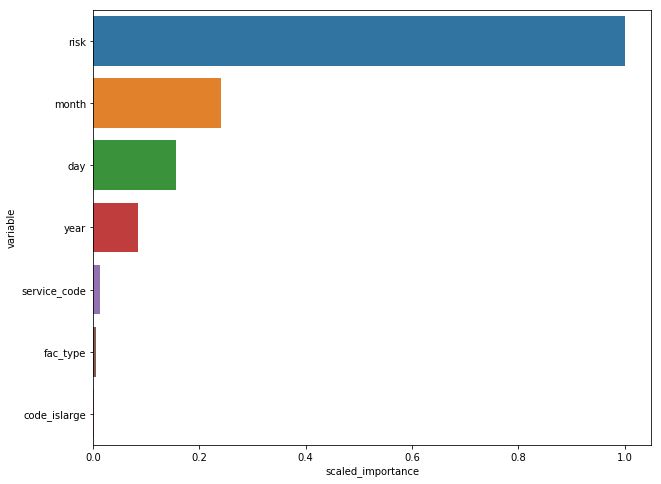

```python
# Feature importance
importance = model_gbm.varimp(use_pandas=True)

fig, ax = plt.subplots(figsize=(10, 8))
sns.barplot(x='scaled_importance', y='variable', data=importance)
plt.show()
```

```python
train_true = train.as_data_frame()['grade'].values
test_true = test.as_data_frame()['grade'].values
train_pred = model_gbm.predict(train).as_data_frame()['p1'].values
test_pred = model_gbm.predict(test).as_data_frame()['p1'].values

train_fpr, train_tpr, _ = roc_curve(train_true, train_pred)
test_fpr, test_tpr, _ = roc_curve(test_true, test_pred)
train_auc = np.round(auc(train_fpr, train_tpr), 3)
test_auc = np.round(auc(test_fpr, test_tpr), 3)
```

```
gbm prediction progress: |████████████████████████████████████████████████| 100%
gbm prediction progress: |████████████████████████████████████████████████| 100%
```

```python
# Classification report
print(classification_report(y_true=test_true, y_pred=(test_pred > 0.5).astype(int)))
```

```
              precision    recall  f1-score   support

           0       0.00      0.00      0.00      1192
           1       0.93      1.00      0.97     16470

   micro avg       0.93      0.93      0.93     17662
   macro avg       0.47      0.50      0.48     17662
weighted avg       0.87      0.93      0.90     17662
```

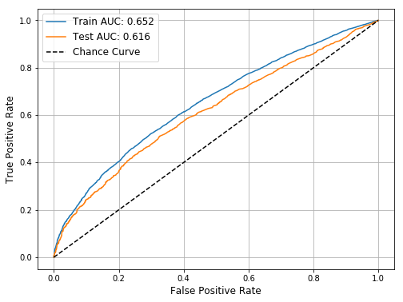

```python
train_fpr = np.insert(train_fpr, 0, 0)
train_tpr = np.insert(train_tpr, 0, 0)
test_fpr = np.insert(test_fpr, 0, 0)
test_tpr = np.insert(test_tpr, 0, 0)

fig, ax = plt.subplots(figsize=(8, 6))
ax.plot(train_fpr, train_tpr, label='Train AUC: ' + str(train_auc))
ax.plot(test_fpr, test_tpr, label='Test AUC: ' + str(test_auc))
ax.plot(train_fpr, train_fpr, 'k--', label='Chance Curve')
ax.set_xlabel('False Positive Rate', fontsize=12)
ax.set_ylabel('True Positive Rate', fontsize=12)
ax.grid(True)
ax.legend(fontsize=12)
plt.show()
```

```
PartialDependencePlot progress: |█████████████████████████████████████████| 100%
```

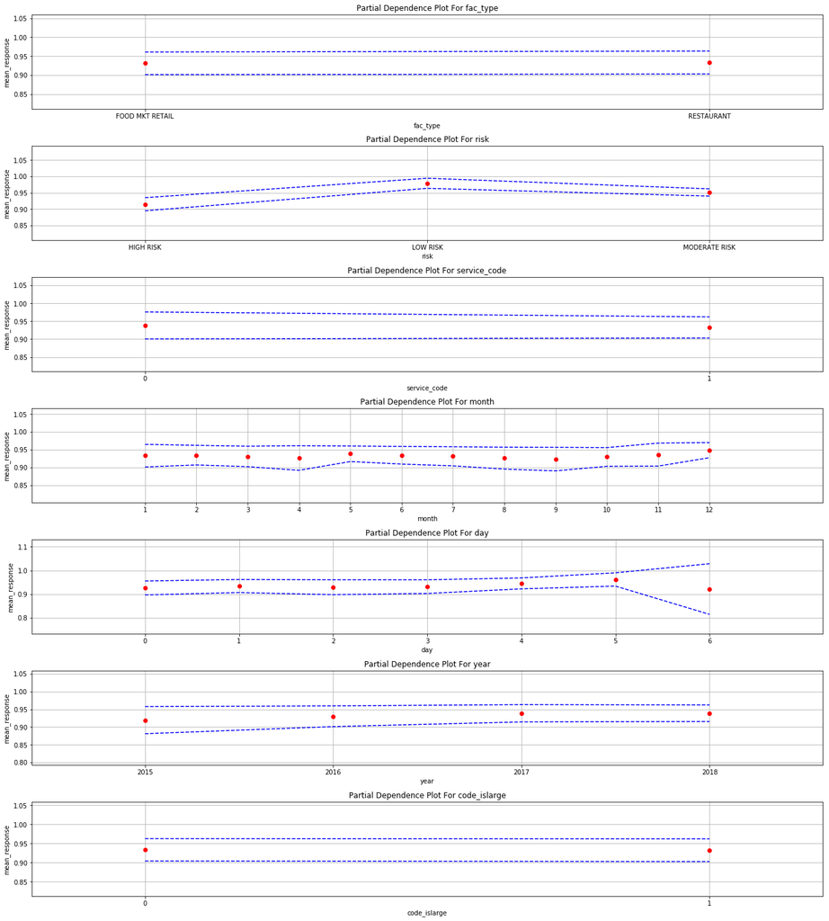

```python
cols = ['fac_type', 'risk','service_code','month','day','year','code_islarge']
_ = model_gbm.partial_plot(data=model_data, cols=cols, nbins=200, figsize=(18, 20))
```

```python
#GLM
from h2o.estimators.glm import H2OGeneralizedLinearEstimator
glm_logistic = H2OGeneralizedLinearEstimator(family = "binomial")
glm_logistic.train(x=feature, y=target, training_frame=train, validation_frame=test,
 model_id="glm_logistic")
```

```
glm Model Build progress: |███████████████████████████████████████████████| 100%
```

```python
train_true = train.as_data_frame()['grade'].values
test_true = test.as_data_frame()['grade'].values
train_pred = glm_logistic.predict(train).as_data_frame()['p1'].values
test_pred = glm_logistic.predict(test).as_data_frame()['p1'].values

train_fpr, train_tpr, _ = roc_curve(train_true, train_pred)
test_fpr, test_tpr, _ = roc_curve(test_true, test_pred)
train_auc = np.round(auc(train_fpr, train_tpr), 3)
test_auc = np.round(auc(test_fpr, test_tpr), 3)
```

```
glm prediction progress: |████████████████████████████████████████████████| 100%
glm prediction progress: |████████████████████████████████████████████████| 100%
```

```python
# Classification report
print(classification_report(y_true=test_true, y_pred=(test_pred > 0.5).astype(int)))
```

```
              precision    recall  f1-score   support

           0       0.00      0.00      0.00      1192
           1       0.93      1.00      0.97     16471

   micro avg       0.93      0.93      0.93     17663
   macro avg       0.47      0.50      0.48     17663
weighted avg       0.87      0.93      0.90     17663
```

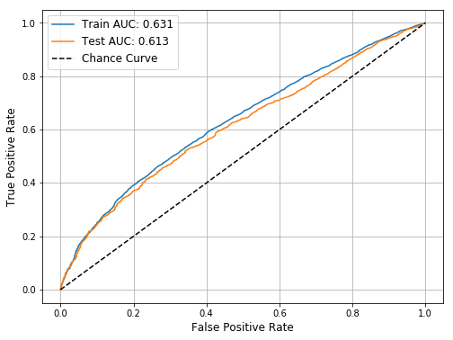

```python
train_fpr = np.insert(train_fpr, 0, 0)
train_tpr = np.insert(train_tpr, 0, 0)
test_fpr = np.insert(test_fpr, 0, 0)
test_tpr = np.insert(test_tpr, 0, 0)

fig, ax = plt.subplots(figsize=(8, 6))
ax.plot(train_fpr, train_tpr, label='Train AUC: ' + str(train_auc))
ax.plot(test_fpr, test_tpr, label='Test AUC: ' + str(test_auc))
ax.plot(train_fpr, train_fpr, 'k--', label='Chance Curve')
ax.set_xlabel('False Positive Rate', fontsize=12)
ax.set_ylabel('True Positive Rate', fontsize=12)
ax.grid(True)
ax.legend(fontsize=12)
plt.show()
```

```
PartialDependencePlot progress: |█████████████████████████████████████████| 100%
```

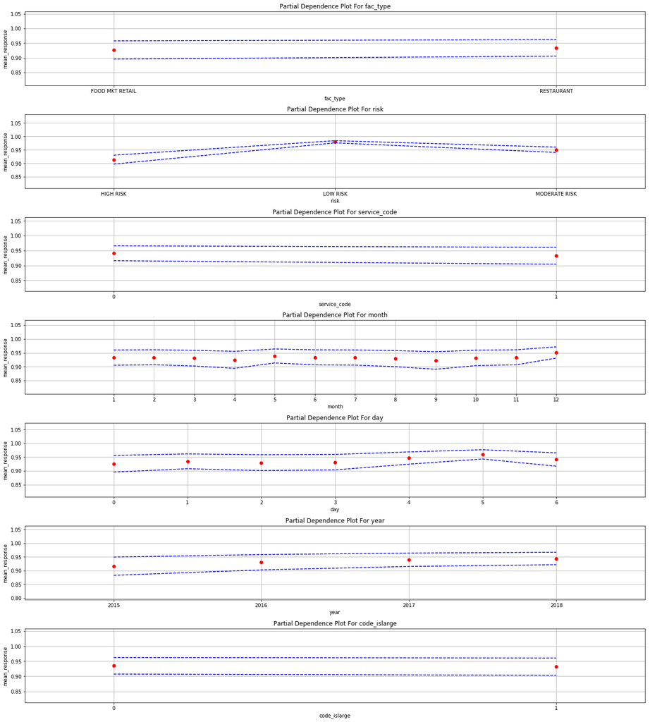

```python
cols = ['fac_type', 'risk','service_code','month','day','year','code_islarge']
_ = glm_logistic.partial_plot(data=model_data, cols=cols, nbins=200, figsize=(18, 20))
```

```python
#random forest
train, test = model_data.split_frame(ratios=[0.7])
rf_model =  H2ORandomForestEstimator(balance_classes=True, ntrees=100, mtries=-1, stopping_rounds=5,
                                 stopping_metric='auc', score_each_iteration=True, seed=42)
rf_model.train(x=feature, y=target, training_frame=train, validation_frame=test)
```

```
drf Model Build progress: |███████████████████████████████████████████████| 100%
```

```python
rf_model.score_history()
```

|  |  | timestamp | duration | number_of_trees | training_rmse | training_logloss | training_auc | training_pr_auc | training_lift | training_classification_error | validation_rmse | validation_logloss | validation_auc | validation_pr_auc | validation_lift | validation_classification_error |
| --- | --- | --- | --- | --- | --- | --- | --- | --- | --- | --- | --- | --- | --- | --- | --- | --- |
| 0 |  | 2019-05-12 00:22:25 | 0.016 sec | 0.0 | NaN | NaN | NaN | NaN | NaN | NaN | NaN | NaN | NaN | NaN | NaN | NaN |
| 1 |  | 2019-05-12 00:22:25 | 0.612 sec | 1.0 | 0.651482 | 1.321879 | 0.641844 | 0.622723 | 1.926916 | 0.486871 | 0.250773 | 0.283387 | 0.605592 | 0.913806 | 1.036812 | 0.067608 |
| 2 |  | 2019-05-12 00:22:25 | 0.895 sec | 2.0 | 0.649030 | 1.303687 | 0.652662 | 0.631565 | 2.000443 | 0.491491 | 0.250112 | 0.259134 | 0.611049 | 0.932399 | 1.046280 | 0.067608 |
| 3 |  | 2019-05-12 00:22:26 | 1.198 sec | 3.0 | 0.650420 | 1.308625 | 0.652237 | 0.640726 | 2.000443 | 0.486088 | 0.250006 | 0.251846 | 0.613343 | 0.947713 | 1.043986 | 0.067608 |
| 4 |  | 2019-05-12 00:22:26 | 1.503 sec | 4.0 | 0.650976 | 1.310314 | 0.656613 | 0.653116 | 2.000443 | 0.481077 | 0.249837 | 0.242437 | 0.616952 | 0.953141 | 1.072510 | 0.067608 |
| 5 |  | 2019-05-12 00:22:26 | 1.792 sec | 5.0 | 0.650587 | 1.307560 | 0.662546 | 0.664057 | 2.000443 | 0.483014 | 0.249854 | 0.242511 | 0.614953 | 0.953885 | 1.061510 | 0.067608 |
| 6 |  | 2019-05-12 00:22:27 | 2.096 sec | 6.0 | 0.650282 | 1.305525 | 0.666585 | 0.676465 | 2.000443 | 0.476787 | 0.249805 | 0.242258 | 0.617302 | 0.955775 | 1.066552 | 0.067608 |
| 7 |  | 2019-05-12 00:22:27 | 2.362 sec | 7.0 | 0.650536 | 1.306695 | 0.666713 | 0.682053 | 1.997838 | 0.482635 | 0.249756 | 0.241956 | 0.618982 | 0.956099 | 1.054635 | 0.067608 |
| 8 |  | 2019-05-12 00:22:27 | 2.535 sec | 8.0 | 0.650530 | 1.305877 | 0.669752 | 0.688396 | 1.997838 | 0.473186 | 0.249712 | 0.241701 | 0.620614 | 0.956466 | 1.054535 | 0.067608 |
| 9 |  | 2019-05-12 00:22:27 | 2.685 sec | 9.0 | 0.650289 | 1.303569 | 0.673098 | 0.694377 | 1.990024 | 0.473021 | 0.249705 | 0.241566 | 0.621153 | 0.956882 | 1.060460 | 0.067608 |
| 10 |  | 2019-05-12 00:22:27 | 2.832 sec | 10.0 | 0.650530 | 1.304652 | 0.674737 | 0.697836 | 1.995240 | 0.471291 | 0.249690 | 0.241464 | 0.621506 | 0.956951 | 1.060527 | 0.067608 |
| 11 |  | 2019-05-12 00:22:28 | 3.001 sec | 11.0 | 0.650392 | 1.303078 | 0.676375 | 0.702045 | 1.995233 | 0.473623 | 0.249673 | 0.241369 | 0.622146 | 0.957157 | 1.060527 | 0.067608 |
| 12 |  | 2019-05-12 00:22:28 | 3.189 sec | 12.0 | 0.650651 | 1.304378 | 0.676862 | 0.703951 | 1.995233 | 0.462636 | 0.249656 | 0.241345 | 0.623209 | 0.957102 | 1.060527 | 0.067608 |
| 13 |  | 2019-05-12 00:22:28 | 3.363 sec | 13.0 | 0.650943 | 1.305480 | 0.678657 | 0.706497 | 1.995233 | 0.460592 | 0.249661 | 0.241344 | 0.623603 | 0.957036 | 1.060659 | 0.067608 |
| 14 |  | 2019-05-12 00:22:28 | 3.545 sec | 14.0 | 0.650970 | 1.305004 | 0.680575 | 0.709492 | 1.995233 | 0.458569 | 0.249664 | 0.241371 | 0.623068 | 0.956983 | 1.060460 | 0.067608 |
| 15 |  | 2019-05-12 00:22:28 | 3.735 sec | 15.0 | 0.650938 | 1.304472 | 0.681711 | 0.711233 | 1.995233 | 0.454492 | 0.249643 | 0.241295 | 0.623886 | 0.957068 | 1.066519 | 0.067608 |
| 16 |  | 2019-05-12 00:22:28 | 3.931 sec | 16.0 | 0.651032 | 1.304773 | 0.681299 | 0.711383 | 1.995233 | 0.453259 | 0.249623 | 0.241179 | 0.624581 | 0.957258 | 1.054832 | 0.067608 |
| 17 |  | 2019-05-12 00:22:29 | 4.127 sec | 17.0 | 0.650985 | 1.304524 | 0.682338 | 0.712745 | 1.997838 | 0.455059 | 0.249642 | 0.241318 | 0.623756 | 0.956978 | 1.054535 | 0.067608 |
| 18 |  | 2019-05-12 00:22:29 | 4.337 sec | 18.0 | 0.651065 | 1.304844 | 0.682184 | 0.713243 | 1.995233 | 0.455142 | 0.249637 | 0.241251 | 0.623651 | 0.957042 | 1.054832 | 0.067608 |
| 19 |  | 2019-05-12 00:22:29 | 4.556 sec | 19.0 | 0.651118 | 1.305106 | 0.682061 | 0.713481 | 1.995233 | 0.461236 | 0.249626 | 0.241153 | 0.623832 | 0.957187 | 1.054734 | 0.067608 |
| 20 |  | 2019-05-12 00:22:29 | 4.813 sec | 20.0 | 0.651033 | 1.304193 | 0.683640 | 0.715303 | 1.995233 | 0.459005 | 0.249638 | 0.241250 | 0.623329 | 0.957033 | 1.054434 | 0.067608 |
| 21 |  | 2019-05-12 00:22:30 | 5.065 sec | 21.0 | 0.651118 | 1.304525 | 0.683398 | 0.715448 | 1.995233 | 0.460622 | 0.249626 | 0.241184 | 0.624099 | 0.957213 | 1.054928 | 0.067608 |

```python
#Make predictions
train_true = train.as_data_frame()['grade'].values
test_true = test.as_data_frame()['grade'].values
train_pred = rf_model.predict(train).as_data_frame()['p1'].values
test_pred = rf_model.predict(test).as_data_frame()['p1'].values

train_fpr, train_tpr, _ = roc_curve(train_true, train_pred)
test_fpr, test_tpr, _ = roc_curve(test_true, test_pred)
train_auc = np.round(auc(train_fpr, train_tpr), 3)
test_auc = np.round(auc(test_fpr, test_tpr), 3)
```

```
drf prediction progress: |████████████████████████████████████████████████| 100%
drf prediction progress: |████████████████████████████████████████████████| 100%
```

```python
print(classification_report(y_true=test_true, y_pred=(test_pred > 0.5).astype(int)))
```

```
              precision    recall  f1-score   support

           0       0.00      0.00      0.00      1197
           1       0.93      1.00      0.97     16508

   micro avg       0.93      0.93      0.93     17705
   macro avg       0.47      0.50      0.48     17705
weighted avg       0.87      0.93      0.90     17705
```

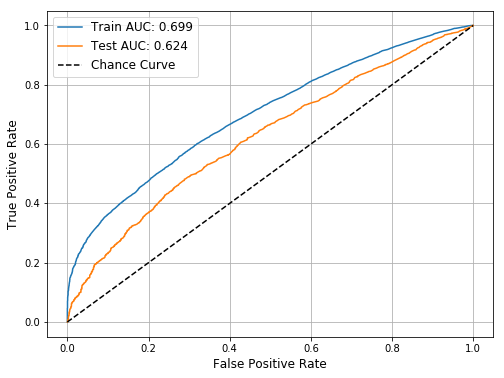

```python
train_fpr = np.insert(train_fpr, 0, 0)
train_tpr = np.insert(train_tpr, 0, 0)
test_fpr = np.insert(test_fpr, 0, 0)
test_tpr = np.insert(test_tpr, 0, 0)
fig, ax = plt.subplots(figsize=(8, 6))
ax.plot(train_fpr, train_tpr, label='Train AUC: ' + str(train_auc))
ax.plot(test_fpr, test_tpr, label='Test AUC: ' + str(test_auc))
ax.plot(train_fpr, train_fpr, 'k--', label='Chance Curve')
ax.set_xlabel('False Positive Rate', fontsize=12)
ax.set_ylabel('True Positive Rate', fontsize=12)
ax.grid(True)
ax.legend(fontsize=12)
plt.show()
```

```
PartialDependencePlot progress: |█████████████████████████████████████████| 100%
```

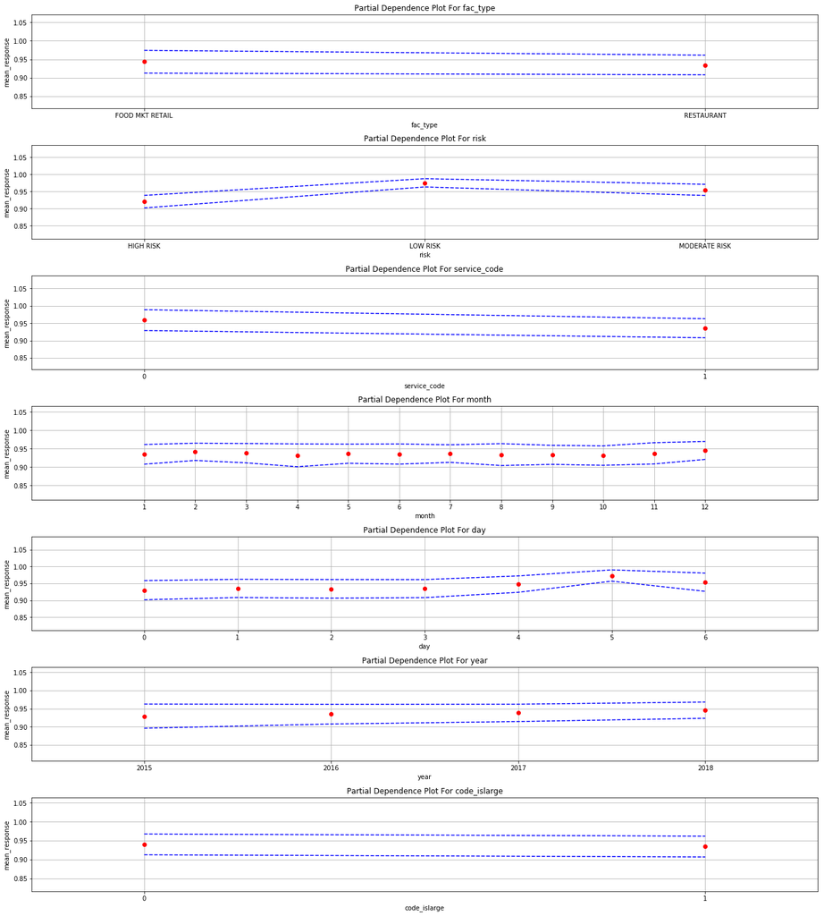

```python
cols = ['fac_type', 'risk','service_code','month','day','year','code_islarge']
_ = rf_model.partial_plot(data=model_data, cols=cols, nbins=200, figsize=(18, 20))
```

```python
#NaiveBayes
from h2o.estimators.naive_bayes import H2ONaiveBayesEstimator
train, test = model_data.split_frame(ratios=[0.7])
naive_bayes =  H2ONaiveBayesEstimator(nfolds=10, seed=42)
naive_bayes.train(x=feature, y=target, training_frame=train, validation_frame=test)
```

```
naivebayes Model Build progress: |████████████████████████████████████████| 100%
```

```python
#Make predictions
train_true = train.as_data_frame()['grade'].values
test_true = test.as_data_frame()['grade'].values
train_pred = naive_bayes.predict(train).as_data_frame()['p1'].values
test_pred = naive_bayes.predict(test).as_data_frame()['p1'].values

train_fpr, train_tpr, _ = roc_curve(train_true, train_pred)
test_fpr, test_tpr, _ = roc_curve(test_true, test_pred)
train_auc = np.round(auc(train_fpr, train_tpr), 3)
test_auc = np.round(auc(test_fpr, test_tpr), 3)
```

```
naivebayes prediction progress: |█████████████████████████████████████████| 100%
naivebayes prediction progress: |█████████████████████████████████████████| 100%
```

```python
print(classification_report(y_true=test_true, y_pred=(test_pred > 0.5).astype(int)))
```

```
              precision    recall  f1-score   support

           0       0.00      0.00      0.00      1183
           1       0.93      1.00      0.97     16438

   micro avg       0.93      0.93      0.93     17621
   macro avg       0.47      0.50      0.48     17621
weighted avg       0.87      0.93      0.90     17621
```

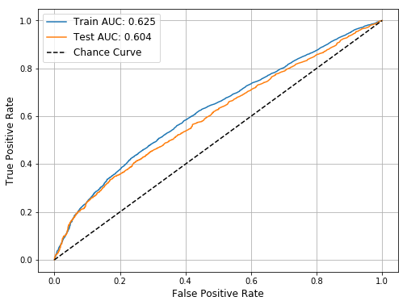

```python
train_fpr = np.insert(train_fpr, 0, 0)
train_tpr = np.insert(train_tpr, 0, 0)
test_fpr = np.insert(test_fpr, 0, 0)
test_tpr = np.insert(test_tpr, 0, 0)
fig, ax = plt.subplots(figsize=(8, 6))
ax.plot(train_fpr, train_tpr, label='Train AUC: ' + str(train_auc))
ax.plot(test_fpr, test_tpr, label='Test AUC: ' + str(test_auc))
ax.plot(train_fpr, train_fpr, 'k--', label='Chance Curve')
ax.set_xlabel('False Positive Rate', fontsize=12)
ax.set_ylabel('True Positive Rate', fontsize=12)
ax.grid(True)
ax.legend(fontsize=12)
plt.show()
```

```
PartialDependencePlot progress: |█████████████████████████████████████████| 100%
```

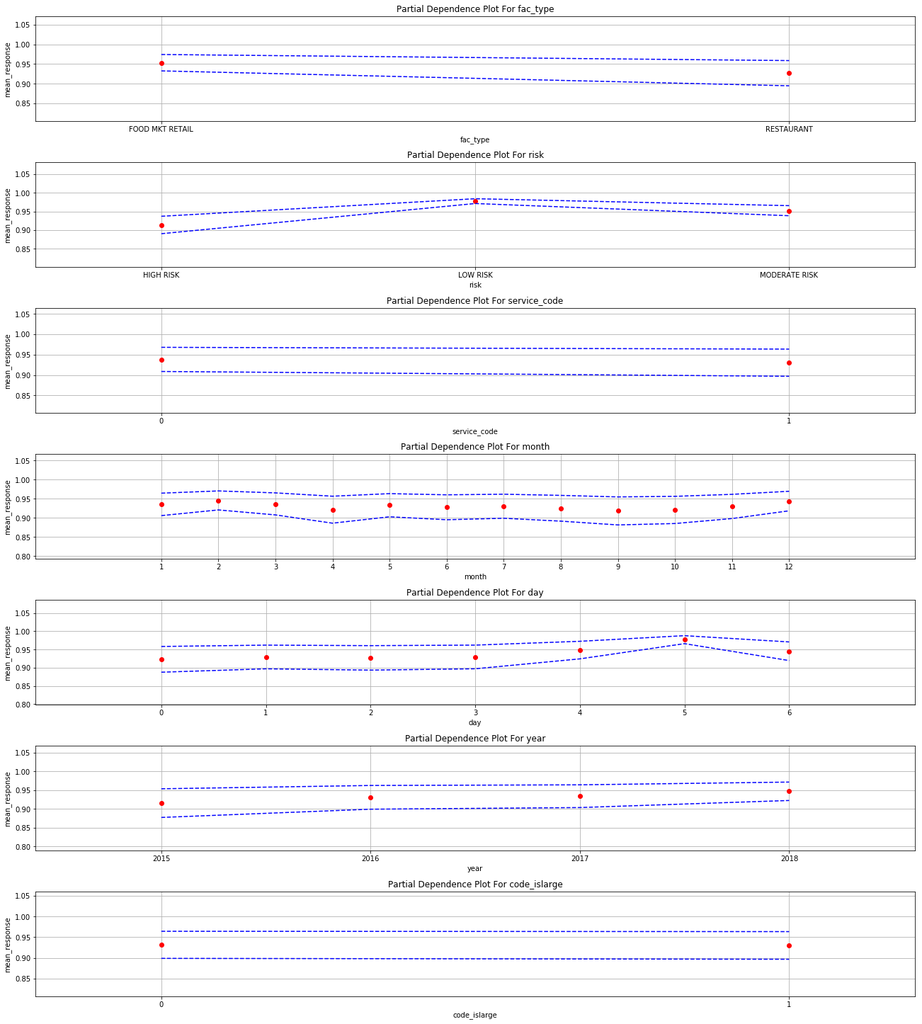

```python
cols = ['fac_type', 'risk','service_code','month','day','year','code_islarge']
_ = naive_bayes.partial_plot(data=model_data, cols=cols, nbins=200, figsize=(18, 20))
```

```python
#deep learning
from h2o.estimators.deeplearning import H2ODeepLearningEstimator
train, test = model_data.split_frame(ratios=[0.7])
neural_network =  H2ODeepLearningEstimator(seed=42)
neural_network.train(x=feature, y=target, training_frame=train, validation_frame=test)
```

```
deeplearning Model Build progress: |██████████████████████████████████████| 100%
```

```python
#Make predictions
train_true = train.as_data_frame()['grade'].values
test_true = test.as_data_frame()['grade'].values
train_pred = neural_network.predict(train).as_data_frame()['p1'].values
test_pred = neural_network.predict(test).as_data_frame()['p1'].values

train_fpr, train_tpr, _ = roc_curve(train_true, train_pred)
test_fpr, test_tpr, _ = roc_curve(test_true, test_pred)
train_auc = np.round(auc(train_fpr, train_tpr), 3)
test_auc = np.round(auc(test_fpr, test_tpr), 3)
```

```
deeplearning prediction progress: |███████████████████████████████████████| 100%
deeplearning prediction progress: |███████████████████████████████████████| 100%
```

```python
print(classification_report(y_true=test_true, y_pred=(test_pred > 0.5).astype(int)))
```

```
              precision    recall  f1-score   support

           0       0.00      0.00      0.00      1206
           1       0.93      1.00      0.96     16592

   micro avg       0.93      0.93      0.93     17798
   macro avg       0.47      0.50      0.48     17798
weighted avg       0.87      0.93      0.90     17798
```

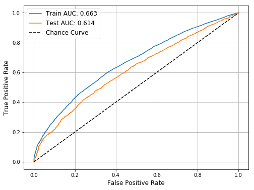

```python
train_fpr = np.insert(train_fpr, 0, 0)
train_tpr = np.insert(train_tpr, 0, 0)
test_fpr = np.insert(test_fpr, 0, 0)
test_tpr = np.insert(test_tpr, 0, 0)
fig, ax = plt.subplots(figsize=(8, 6))
ax.plot(train_fpr, train_tpr, label='Train AUC: ' + str(train_auc))
ax.plot(test_fpr, test_tpr, label='Test AUC: ' + str(test_auc))
ax.plot(train_fpr, train_fpr, 'k--', label='Chance Curve')
ax.set_xlabel('False Positive Rate', fontsize=12)
ax.set_ylabel('True Positive Rate', fontsize=12)
ax.grid(True)
ax.legend(fontsize=12)
plt.show()
```

```
PartialDependencePlot progress: |█████████████████████████████████████████| 100%
```

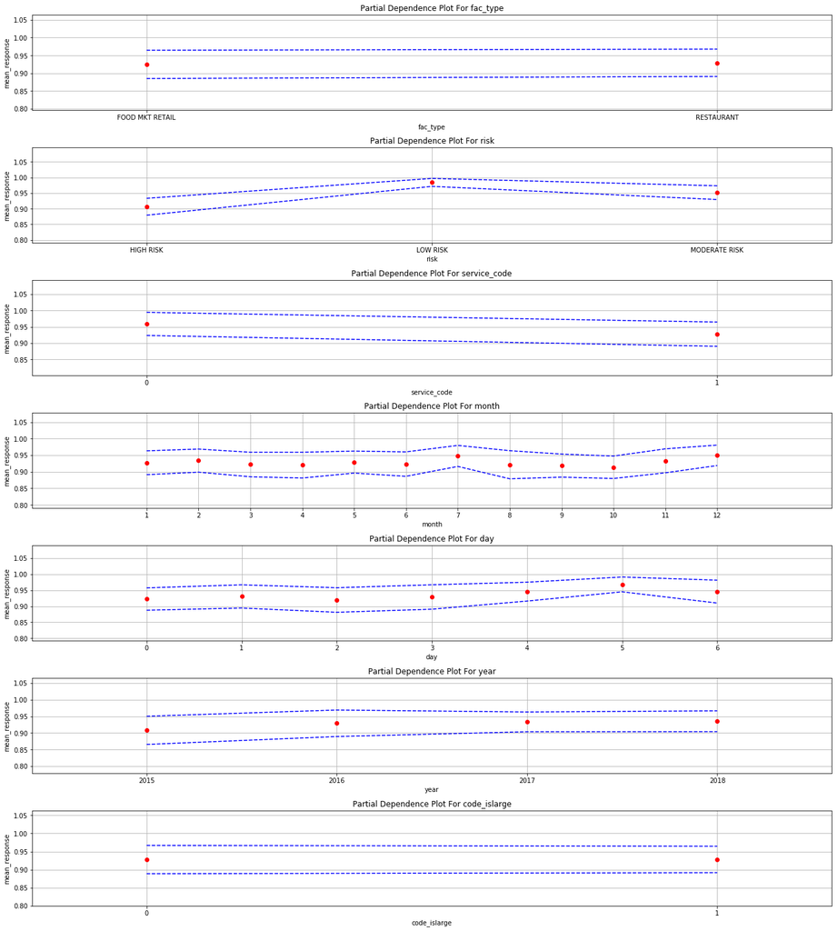

```python
cols = ['fac_type', 'risk','service_code','month','day','year','code_islarge']
_ = neural_network.partial_plot(data=model_data, cols=cols, nbins=200, figsize=(18, 20))
```

```python
# Shutdown h2o
h2o.cluster().shutdown()
```

```
H2O session _sid_84c6 closed.
```